# Project: Wrangling and Analyze Data

### Project Details

#### A data wrangling project which involves:

##### Gathering data from three sources

- From twitter_archived_enhanced
- From a image url
- From twitter API ##### Storing the data ##### Analysing and visualizing the wrangled data ##### Reporting on:
- Data wrangling process
- Data analysis and visualization

## Data Gathering

In the cell below, gather **all** three pieces of data for this project and load them in the notebook. **Note:** the methods required to gather each data are different.

1. Directly download the WeRateDogs Twitter archive data (twitter_archive_enhanced.csv)

```python
#import libraries
import numpy as np
import pandas as pd
import matplotlib.pyplot as plt
import seaborn as sns
%matplotlib inline

import tweepy
from tweepy import OAuthHandler
import json
from timeit import default_timer as timer

import requests
from operator import itemgetter
```

```python
# load dataset
twitter_archived_enhanced = pd.read_csv('twitter-archive-enhanced.csv')
twitter_archived_enhanced.head(2)
```

|  | tweet_id | in_reply_to_status_id | in_reply_to_user_id | timestamp | source | text | retweeted_status_id | retweeted_status_user_id | retweeted_status_timestamp | expanded_urls | rating_numerator | rating_denominator | name | doggo | floofer | pupper | puppo |
| --- | --- | --- | --- | --- | --- | --- | --- | --- | --- | --- | --- | --- | --- | --- | --- | --- | --- |
| 0 | 892420643555336193 | NaN | NaN | 2017-08-01 16:23:56 +0000 | <a href="http://twitter.com/download/iphone" r... | This is Phineas. He's a mystical boy. Only eve... | NaN | NaN | NaN | https://twitter.com/dog_rates/status/892420643... | 13 | 10 | Phineas | None | None | None | None |
| 1 | 892177421306343426 | NaN | NaN | 2017-08-01 00:17:27 +0000 | <a href="http://twitter.com/download/iphone" r... | This is Tilly. She's just checking pup on you.... | NaN | NaN | NaN | https://twitter.com/dog_rates/status/892177421... | 13 | 10 | Tilly | None | None | None | None |

1. Use the Requests library to download the tweet image prediction (image_predictions.tsv)

```python
# download 2nd dataset programmatically
url = ' https://d17h27t6h515a5.cloudfront.net/topher/2017/August/599fd2ad_image-predictions/image-predictions.tsv'
response = requests.get(url)

with open('image-predictions.tsv', mode='wb') as f:
    f.write(response.content)
```

```python
# load 2nd dataset
img_predictions = pd.read_csv('image-predictions.tsv', sep='\t')
```

1. Use the Request library to query additional data via the Twitter API (tweet_json.txt), using this because the twitter API token provided by udacity expired and was having issues getting the API token directly from twitter

```python
#Loading third data programmatically as the twitter API token have expire
url = 'https://video.udacity-data.com/topher/2018/November/5be5fb7d_tweet-json/tweet-json.txt'
response = requests.get(url)

with open('tweet-json.txt', mode='wb') as f:
    f.write(response.content)
data = 'tweet-json.txt'

with open(data, 'r') as f:
    jdata = [json.loads(line) for line in f]
data = list(map(itemgetter('id','retweet_count','favorite_count'), jdata))
data[0:4]
```

```
[(892420643555336193, 8853, 39467),
 (892177421306343426, 6514, 33819),
 (891815181378084864, 4328, 25461),
 (891689557279858688, 8964, 42908)]
```

```python
# load into pandas dataframe and add column names
df = pd.DataFrame(data, columns=['tweet_id','retweet_count','favorite_count'])
df.head(3)
```

|  | tweet_id | retweet_count | favorite_count |
| --- | --- | --- | --- |
| 0 | 892420643555336193 | 8853 | 39467 |
| 1 | 892177421306343426 | 6514 | 33819 |
| 2 | 891815181378084864 | 4328 | 25461 |

## Assessing Data

```python
# load the datasets
twitter_archived_enhanced = pd.read_csv('twitter-archive-enhanced.csv')
img_predictions = pd.read_csv('image-predictions.tsv', sep='\t')
tweet_fav_counts = pd.read_csv('tweet_json.csv')
```

### Visual Assessment

Each dataset is gathered and loaded into the jupyter notebook for visual assessment

```python
twitter_archived_enhanced
```

|  | tweet_id | in_reply_to_status_id | in_reply_to_user_id | timestamp | source | text | retweeted_status_id | retweeted_status_user_id | retweeted_status_timestamp | expanded_urls | rating_numerator | rating_denominator | name | doggo | floofer | pupper | puppo |
| --- | --- | --- | --- | --- | --- | --- | --- | --- | --- | --- | --- | --- | --- | --- | --- | --- | --- |
| 0 | 892420643555336193 | NaN | NaN | 2017-08-01 16:23:56 +0000 | <a href="http://twitter.com/download/iphone" r... | This is Phineas. He's a mystical boy. Only eve... | NaN | NaN | NaN | https://twitter.com/dog_rates/status/892420643... | 13 | 10 | Phineas | None | None | None | None |
| 1 | 892177421306343426 | NaN | NaN | 2017-08-01 00:17:27 +0000 | <a href="http://twitter.com/download/iphone" r... | This is Tilly. She's just checking pup on you.... | NaN | NaN | NaN | https://twitter.com/dog_rates/status/892177421... | 13 | 10 | Tilly | None | None | None | None |
| 2 | 891815181378084864 | NaN | NaN | 2017-07-31 00:18:03 +0000 | <a href="http://twitter.com/download/iphone" r... | This is Archie. He is a rare Norwegian Pouncin... | NaN | NaN | NaN | https://twitter.com/dog_rates/status/891815181... | 12 | 10 | Archie | None | None | None | None |
| 3 | 891689557279858688 | NaN | NaN | 2017-07-30 15:58:51 +0000 | <a href="http://twitter.com/download/iphone" r... | This is Darla. She commenced a snooze mid meal... | NaN | NaN | NaN | https://twitter.com/dog_rates/status/891689557... | 13 | 10 | Darla | None | None | None | None |
| 4 | 891327558926688256 | NaN | NaN | 2017-07-29 16:00:24 +0000 | <a href="http://twitter.com/download/iphone" r... | This is Franklin. He would like you to stop ca... | NaN | NaN | NaN | https://twitter.com/dog_rates/status/891327558... | 12 | 10 | Franklin | None | None | None | None |
| 5 | 891087950875897856 | NaN | NaN | 2017-07-29 00:08:17 +0000 | <a href="http://twitter.com/download/iphone" r... | Here we have a majestic great white breaching ... | NaN | NaN | NaN | https://twitter.com/dog_rates/status/891087950... | 13 | 10 | None | None | None | None | None |
| 6 | 890971913173991426 | NaN | NaN | 2017-07-28 16:27:12 +0000 | <a href="http://twitter.com/download/iphone" r... | Meet Jax. He enjoys ice cream so much he gets ... | NaN | NaN | NaN | https://gofundme.com/ydvmve-surgery-for-jax,ht... | 13 | 10 | Jax | None | None | None | None |
| 7 | 890729181411237888 | NaN | NaN | 2017-07-28 00:22:40 +0000 | <a href="http://twitter.com/download/iphone" r... | When you watch your owner call another dog a g... | NaN | NaN | NaN | https://twitter.com/dog_rates/status/890729181... | 13 | 10 | None | None | None | None | None |
| 8 | 890609185150312448 | NaN | NaN | 2017-07-27 16:25:51 +0000 | <a href="http://twitter.com/download/iphone" r... | This is Zoey. She doesn't want to be one of th... | NaN | NaN | NaN | https://twitter.com/dog_rates/status/890609185... | 13 | 10 | Zoey | None | None | None | None |
| 9 | 890240255349198849 | NaN | NaN | 2017-07-26 15:59:51 +0000 | <a href="http://twitter.com/download/iphone" r... | This is Cassie. She is a college pup. Studying... | NaN | NaN | NaN | https://twitter.com/dog_rates/status/890240255... | 14 | 10 | Cassie | doggo | None | None | None |
| 10 | 890006608113172480 | NaN | NaN | 2017-07-26 00:31:25 +0000 | <a href="http://twitter.com/download/iphone" r... | This is Koda. He is a South Australian decksha... | NaN | NaN | NaN | https://twitter.com/dog_rates/status/890006608... | 13 | 10 | Koda | None | None | None | None |
| 11 | 889880896479866881 | NaN | NaN | 2017-07-25 16:11:53 +0000 | <a href="http://twitter.com/download/iphone" r... | This is Bruno. He is a service shark. Only get... | NaN | NaN | NaN | https://twitter.com/dog_rates/status/889880896... | 13 | 10 | Bruno | None | None | None | None |
| 12 | 889665388333682689 | NaN | NaN | 2017-07-25 01:55:32 +0000 | <a href="http://twitter.com/download/iphone" r... | Here's a puppo that seems to be on the fence a... | NaN | NaN | NaN | https://twitter.com/dog_rates/status/889665388... | 13 | 10 | None | None | None | None | puppo |
| 13 | 889638837579907072 | NaN | NaN | 2017-07-25 00:10:02 +0000 | <a href="http://twitter.com/download/iphone" r... | This is Ted. He does his best. Sometimes that'... | NaN | NaN | NaN | https://twitter.com/dog_rates/status/889638837... | 12 | 10 | Ted | None | None | None | None |
| 14 | 889531135344209921 | NaN | NaN | 2017-07-24 17:02:04 +0000 | <a href="http://twitter.com/download/iphone" r... | This is Stuart. He's sporting his favorite fan... | NaN | NaN | NaN | https://twitter.com/dog_rates/status/889531135... | 13 | 10 | Stuart | None | None | None | puppo |
| 15 | 889278841981685760 | NaN | NaN | 2017-07-24 00:19:32 +0000 | <a href="http://twitter.com/download/iphone" r... | This is Oliver. You're witnessing one of his m... | NaN | NaN | NaN | https://twitter.com/dog_rates/status/889278841... | 13 | 10 | Oliver | None | None | None | None |
| 16 | 888917238123831296 | NaN | NaN | 2017-07-23 00:22:39 +0000 | <a href="http://twitter.com/download/iphone" r... | This is Jim. He found a fren. Taught him how t... | NaN | NaN | NaN | https://twitter.com/dog_rates/status/888917238... | 12 | 10 | Jim | None | None | None | None |
| 17 | 888804989199671297 | NaN | NaN | 2017-07-22 16:56:37 +0000 | <a href="http://twitter.com/download/iphone" r... | This is Zeke. He has a new stick. Very proud o... | NaN | NaN | NaN | https://twitter.com/dog_rates/status/888804989... | 13 | 10 | Zeke | None | None | None | None |
| 18 | 888554962724278272 | NaN | NaN | 2017-07-22 00:23:06 +0000 | <a href="http://twitter.com/download/iphone" r... | This is Ralphus. He's powering up. Attempting ... | NaN | NaN | NaN | https://twitter.com/dog_rates/status/888554962... | 13 | 10 | Ralphus | None | None | None | None |
| 19 | 888202515573088257 | NaN | NaN | 2017-07-21 01:02:36 +0000 | <a href="http://twitter.com/download/iphone" r... | RT @dog_rates: This is Canela. She attempted s... | 8.874740e+17 | 4.196984e+09 | 2017-07-19 00:47:34 +0000 | https://twitter.com/dog_rates/status/887473957... | 13 | 10 | Canela | None | None | None | None |
| 20 | 888078434458587136 | NaN | NaN | 2017-07-20 16:49:33 +0000 | <a href="http://twitter.com/download/iphone" r... | This is Gerald. He was just told he didn't get... | NaN | NaN | NaN | https://twitter.com/dog_rates/status/888078434... | 12 | 10 | Gerald | None | None | None | None |
| 21 | 887705289381826560 | NaN | NaN | 2017-07-19 16:06:48 +0000 | <a href="http://twitter.com/download/iphone" r... | This is Jeffrey. He has a monopoly on the pool... | NaN | NaN | NaN | https://twitter.com/dog_rates/status/887705289... | 13 | 10 | Jeffrey | None | None | None | None |
| 22 | 887517139158093824 | NaN | NaN | 2017-07-19 03:39:09 +0000 | <a href="http://twitter.com/download/iphone" r... | I've yet to rate a Venezuelan Hover Wiener. Th... | NaN | NaN | NaN | https://twitter.com/dog_rates/status/887517139... | 14 | 10 | such | None | None | None | None |
| 23 | 887473957103951883 | NaN | NaN | 2017-07-19 00:47:34 +0000 | <a href="http://twitter.com/download/iphone" r... | This is Canela. She attempted some fancy porch... | NaN | NaN | NaN | https://twitter.com/dog_rates/status/887473957... | 13 | 10 | Canela | None | None | None | None |
| 24 | 887343217045368832 | NaN | NaN | 2017-07-18 16:08:03 +0000 | <a href="http://twitter.com/download/iphone" r... | You may not have known you needed to see this ... | NaN | NaN | NaN | https://twitter.com/dog_rates/status/887343217... | 13 | 10 | None | None | None | None | None |
| 25 | 887101392804085760 | NaN | NaN | 2017-07-18 00:07:08 +0000 | <a href="http://twitter.com/download/iphone" r... | This... is a Jubilant Antarctic House Bear. We... | NaN | NaN | NaN | https://twitter.com/dog_rates/status/887101392... | 12 | 10 | None | None | None | None | None |
| 26 | 886983233522544640 | NaN | NaN | 2017-07-17 16:17:36 +0000 | <a href="http://twitter.com/download/iphone" r... | This is Maya. She's very shy. Rarely leaves he... | NaN | NaN | NaN | https://twitter.com/dog_rates/status/886983233... | 13 | 10 | Maya | None | None | None | None |
| 27 | 886736880519319552 | NaN | NaN | 2017-07-16 23:58:41 +0000 | <a href="http://twitter.com/download/iphone" r... | This is Mingus. He's a wonderful father to his... | NaN | NaN | NaN | https://www.gofundme.com/mingusneedsus,https:/... | 13 | 10 | Mingus | None | None | None | None |
| 28 | 886680336477933568 | NaN | NaN | 2017-07-16 20:14:00 +0000 | <a href="http://twitter.com/download/iphone" r... | This is Derek. He's late for a dog meeting. 13... | NaN | NaN | NaN | https://twitter.com/dog_rates/status/886680336... | 13 | 10 | Derek | None | None | None | None |
| 29 | 886366144734445568 | NaN | NaN | 2017-07-15 23:25:31 +0000 | <a href="http://twitter.com/download/iphone" r... | This is Roscoe. Another pupper fallen victim t... | NaN | NaN | NaN | https://twitter.com/dog_rates/status/886366144... | 12 | 10 | Roscoe | None | None | pupper | None |
| ... | ... | ... | ... | ... | ... | ... | ... | ... | ... | ... | ... | ... | ... | ... | ... | ... | ... |
| 2326 | 666411507551481857 | NaN | NaN | 2015-11-17 00:24:19 +0000 | <a href="http://twitter.com/download/iphone" r... | This is quite the dog. Gets really excited whe... | NaN | NaN | NaN | https://twitter.com/dog_rates/status/666411507... | 2 | 10 | quite | None | None | None | None |
| 2327 | 666407126856765440 | NaN | NaN | 2015-11-17 00:06:54 +0000 | <a href="http://twitter.com/download/iphone" r... | This is a southern Vesuvius bumblegruff. Can d... | NaN | NaN | NaN | https://twitter.com/dog_rates/status/666407126... | 7 | 10 | a | None | None | None | None |
| 2328 | 666396247373291520 | NaN | NaN | 2015-11-16 23:23:41 +0000 | <a href="http://twitter.com/download/iphone" r... | Oh goodness. A super rare northeast Qdoba kang... | NaN | NaN | NaN | https://twitter.com/dog_rates/status/666396247... | 9 | 10 | None | None | None | None | None |
| 2329 | 666373753744588802 | NaN | NaN | 2015-11-16 21:54:18 +0000 | <a href="http://twitter.com/download/iphone" r... | Those are sunglasses and a jean jacket. 11/10 ... | NaN | NaN | NaN | https://twitter.com/dog_rates/status/666373753... | 11 | 10 | None | None | None | None | None |
| 2330 | 666362758909284353 | NaN | NaN | 2015-11-16 21:10:36 +0000 | <a href="http://twitter.com/download/iphone" r... | Unique dog here. Very small. Lives in containe... | NaN | NaN | NaN | https://twitter.com/dog_rates/status/666362758... | 6 | 10 | None | None | None | None | None |
| 2331 | 666353288456101888 | NaN | NaN | 2015-11-16 20:32:58 +0000 | <a href="http://twitter.com/download/iphone" r... | Here we have a mixed Asiago from the Galápagos... | NaN | NaN | NaN | https://twitter.com/dog_rates/status/666353288... | 8 | 10 | None | None | None | None | None |
| 2332 | 666345417576210432 | NaN | NaN | 2015-11-16 20:01:42 +0000 | <a href="http://twitter.com/download/iphone" r... | Look at this jokester thinking seat belt laws ... | NaN | NaN | NaN | https://twitter.com/dog_rates/status/666345417... | 10 | 10 | None | None | None | None | None |
| 2333 | 666337882303524864 | NaN | NaN | 2015-11-16 19:31:45 +0000 | <a href="http://twitter.com/download/iphone" r... | This is an extremely rare horned Parthenon. No... | NaN | NaN | NaN | https://twitter.com/dog_rates/status/666337882... | 9 | 10 | an | None | None | None | None |
| 2334 | 666293911632134144 | NaN | NaN | 2015-11-16 16:37:02 +0000 | <a href="http://twitter.com/download/iphone" r... | This is a funny dog. Weird toes. Won't come do... | NaN | NaN | NaN | https://twitter.com/dog_rates/status/666293911... | 3 | 10 | a | None | None | None | None |
| 2335 | 666287406224695296 | NaN | NaN | 2015-11-16 16:11:11 +0000 | <a href="http://twitter.com/download/iphone" r... | This is an Albanian 3 1/2 legged Episcopalian... | NaN | NaN | NaN | https://twitter.com/dog_rates/status/666287406... | 1 | 2 | an | None | None | None | None |
| 2336 | 666273097616637952 | NaN | NaN | 2015-11-16 15:14:19 +0000 | <a href="http://twitter.com/download/iphone" r... | Can take selfies 11/10 https://t.co/ws2AMaNwPW | NaN | NaN | NaN | https://twitter.com/dog_rates/status/666273097... | 11 | 10 | None | None | None | None | None |
| 2337 | 666268910803644416 | NaN | NaN | 2015-11-16 14:57:41 +0000 | <a href="http://twitter.com/download/iphone" r... | Very concerned about fellow dog trapped in com... | NaN | NaN | NaN | https://twitter.com/dog_rates/status/666268910... | 10 | 10 | None | None | None | None | None |
| 2338 | 666104133288665088 | NaN | NaN | 2015-11-16 04:02:55 +0000 | <a href="http://twitter.com/download/iphone" r... | Not familiar with this breed. No tail (weird).... | NaN | NaN | NaN | https://twitter.com/dog_rates/status/666104133... | 1 | 10 | None | None | None | None | None |
| 2339 | 666102155909144576 | NaN | NaN | 2015-11-16 03:55:04 +0000 | <a href="http://twitter.com/download/iphone" r... | Oh my. Here you are seeing an Adobe Setter giv... | NaN | NaN | NaN | https://twitter.com/dog_rates/status/666102155... | 11 | 10 | None | None | None | None | None |
| 2340 | 666099513787052032 | NaN | NaN | 2015-11-16 03:44:34 +0000 | <a href="http://twitter.com/download/iphone" r... | Can stand on stump for what seems like a while... | NaN | NaN | NaN | https://twitter.com/dog_rates/status/666099513... | 8 | 10 | None | None | None | None | None |
| 2341 | 666094000022159362 | NaN | NaN | 2015-11-16 03:22:39 +0000 | <a href="http://twitter.com/download/iphone" r... | This appears to be a Mongolian Presbyterian mi... | NaN | NaN | NaN | https://twitter.com/dog_rates/status/666094000... | 9 | 10 | None | None | None | None | None |
| 2342 | 666082916733198337 | NaN | NaN | 2015-11-16 02:38:37 +0000 | <a href="http://twitter.com/download/iphone" r... | Here we have a well-established sunblockerspan... | NaN | NaN | NaN | https://twitter.com/dog_rates/status/666082916... | 6 | 10 | None | None | None | None | None |
| 2343 | 666073100786774016 | NaN | NaN | 2015-11-16 01:59:36 +0000 | <a href="http://twitter.com/download/iphone" r... | Let's hope this flight isn't Malaysian (lol). ... | NaN | NaN | NaN | https://twitter.com/dog_rates/status/666073100... | 10 | 10 | None | None | None | None | None |
| 2344 | 666071193221509120 | NaN | NaN | 2015-11-16 01:52:02 +0000 | <a href="http://twitter.com/download/iphone" r... | Here we have a northern speckled Rhododendron.... | NaN | NaN | NaN | https://twitter.com/dog_rates/status/666071193... | 9 | 10 | None | None | None | None | None |
| 2345 | 666063827256086533 | NaN | NaN | 2015-11-16 01:22:45 +0000 | <a href="http://twitter.com/download/iphone" r... | This is the happiest dog you will ever see. Ve... | NaN | NaN | NaN | https://twitter.com/dog_rates/status/666063827... | 10 | 10 | the | None | None | None | None |
| 2346 | 666058600524156928 | NaN | NaN | 2015-11-16 01:01:59 +0000 | <a href="http://twitter.com/download/iphone" r... | Here is the Rand Paul of retrievers folks! He'... | NaN | NaN | NaN | https://twitter.com/dog_rates/status/666058600... | 8 | 10 | the | None | None | None | None |
| 2347 | 666057090499244032 | NaN | NaN | 2015-11-16 00:55:59 +0000 | <a href="http://twitter.com/download/iphone" r... | My oh my. This is a rare blond Canadian terrie... | NaN | NaN | NaN | https://twitter.com/dog_rates/status/666057090... | 9 | 10 | a | None | None | None | None |
| 2348 | 666055525042405380 | NaN | NaN | 2015-11-16 00:49:46 +0000 | <a href="http://twitter.com/download/iphone" r... | Here is a Siberian heavily armored polar bear ... | NaN | NaN | NaN | https://twitter.com/dog_rates/status/666055525... | 10 | 10 | a | None | None | None | None |
| 2349 | 666051853826850816 | NaN | NaN | 2015-11-16 00:35:11 +0000 | <a href="http://twitter.com/download/iphone" r... | This is an odd dog. Hard on the outside but lo... | NaN | NaN | NaN | https://twitter.com/dog_rates/status/666051853... | 2 | 10 | an | None | None | None | None |
| 2350 | 666050758794694657 | NaN | NaN | 2015-11-16 00:30:50 +0000 | <a href="http://twitter.com/download/iphone" r... | This is a truly beautiful English Wilson Staff... | NaN | NaN | NaN | https://twitter.com/dog_rates/status/666050758... | 10 | 10 | a | None | None | None | None |
| 2351 | 666049248165822465 | NaN | NaN | 2015-11-16 00:24:50 +0000 | <a href="http://twitter.com/download/iphone" r... | Here we have a 1949 1st generation vulpix. Enj... | NaN | NaN | NaN | https://twitter.com/dog_rates/status/666049248... | 5 | 10 | None | None | None | None | None |
| 2352 | 666044226329800704 | NaN | NaN | 2015-11-16 00:04:52 +0000 | <a href="http://twitter.com/download/iphone" r... | This is a purebred Piers Morgan. Loves to Netf... | NaN | NaN | NaN | https://twitter.com/dog_rates/status/666044226... | 6 | 10 | a | None | None | None | None |
| 2353 | 666033412701032449 | NaN | NaN | 2015-11-15 23:21:54 +0000 | <a href="http://twitter.com/download/iphone" r... | Here is a very happy pup. Big fan of well-main... | NaN | NaN | NaN | https://twitter.com/dog_rates/status/666033412... | 9 | 10 | a | None | None | None | None |
| 2354 | 666029285002620928 | NaN | NaN | 2015-11-15 23:05:30 +0000 | <a href="http://twitter.com/download/iphone" r... | This is a western brown Mitsubishi terrier. Up... | NaN | NaN | NaN | https://twitter.com/dog_rates/status/666029285... | 7 | 10 | a | None | None | None | None |
| 2355 | 666020888022790149 | NaN | NaN | 2015-11-15 22:32:08 +0000 | <a href="http://twitter.com/download/iphone" r... | Here we have a Japanese Irish Setter. Lost eye... | NaN | NaN | NaN | https://twitter.com/dog_rates/status/666020888... | 8 | 10 | None | None | None | None | None |

2356 rows × 17 columns

```python
img_predictions
```

|  | tweet_id | jpg_url | img_num | p1 | p1_conf | p1_dog | p2 | p2_conf | p2_dog | p3 | p3_conf | p3_dog |
| --- | --- | --- | --- | --- | --- | --- | --- | --- | --- | --- | --- | --- |
| 0 | 666020888022790149 | https://pbs.twimg.com/media/CT4udn0WwAA0aMy.jpg | 1 | Welsh_springer_spaniel | 0.465074 | True | collie | 0.156665 | True | Shetland_sheepdog | 0.061428 | True |
| 1 | 666029285002620928 | https://pbs.twimg.com/media/CT42GRgUYAA5iDo.jpg | 1 | redbone | 0.506826 | True | miniature_pinscher | 0.074192 | True | Rhodesian_ridgeback | 0.072010 | True |
| 2 | 666033412701032449 | https://pbs.twimg.com/media/CT4521TWwAEvMyu.jpg | 1 | German_shepherd | 0.596461 | True | malinois | 0.138584 | True | bloodhound | 0.116197 | True |
| 3 | 666044226329800704 | https://pbs.twimg.com/media/CT5Dr8HUEAA-lEu.jpg | 1 | Rhodesian_ridgeback | 0.408143 | True | redbone | 0.360687 | True | miniature_pinscher | 0.222752 | True |
| 4 | 666049248165822465 | https://pbs.twimg.com/media/CT5IQmsXIAAKY4A.jpg | 1 | miniature_pinscher | 0.560311 | True | Rottweiler | 0.243682 | True | Doberman | 0.154629 | True |
| 5 | 666050758794694657 | https://pbs.twimg.com/media/CT5Jof1WUAEuVxN.jpg | 1 | Bernese_mountain_dog | 0.651137 | True | English_springer | 0.263788 | True | Greater_Swiss_Mountain_dog | 0.016199 | True |
| 6 | 666051853826850816 | https://pbs.twimg.com/media/CT5KoJ1WoAAJash.jpg | 1 | box_turtle | 0.933012 | False | mud_turtle | 0.045885 | False | terrapin | 0.017885 | False |
| 7 | 666055525042405380 | https://pbs.twimg.com/media/CT5N9tpXIAAifs1.jpg | 1 | chow | 0.692517 | True | Tibetan_mastiff | 0.058279 | True | fur_coat | 0.054449 | False |
| 8 | 666057090499244032 | https://pbs.twimg.com/media/CT5PY90WoAAQGLo.jpg | 1 | shopping_cart | 0.962465 | False | shopping_basket | 0.014594 | False | golden_retriever | 0.007959 | True |
| 9 | 666058600524156928 | https://pbs.twimg.com/media/CT5Qw94XAAA_2dP.jpg | 1 | miniature_poodle | 0.201493 | True | komondor | 0.192305 | True | soft-coated_wheaten_terrier | 0.082086 | True |
| 10 | 666063827256086533 | https://pbs.twimg.com/media/CT5Vg_wXIAAXfnj.jpg | 1 | golden_retriever | 0.775930 | True | Tibetan_mastiff | 0.093718 | True | Labrador_retriever | 0.072427 | True |
| 11 | 666071193221509120 | https://pbs.twimg.com/media/CT5cN_3WEAAlOoZ.jpg | 1 | Gordon_setter | 0.503672 | True | Yorkshire_terrier | 0.174201 | True | Pekinese | 0.109454 | True |
| 12 | 666073100786774016 | https://pbs.twimg.com/media/CT5d9DZXAAALcwe.jpg | 1 | Walker_hound | 0.260857 | True | English_foxhound | 0.175382 | True | Ibizan_hound | 0.097471 | True |
| 13 | 666082916733198337 | https://pbs.twimg.com/media/CT5m4VGWEAAtKc8.jpg | 1 | pug | 0.489814 | True | bull_mastiff | 0.404722 | True | French_bulldog | 0.048960 | True |
| 14 | 666094000022159362 | https://pbs.twimg.com/media/CT5w9gUW4AAsBNN.jpg | 1 | bloodhound | 0.195217 | True | German_shepherd | 0.078260 | True | malinois | 0.075628 | True |
| 15 | 666099513787052032 | https://pbs.twimg.com/media/CT51-JJUEAA6hV8.jpg | 1 | Lhasa | 0.582330 | True | Shih-Tzu | 0.166192 | True | Dandie_Dinmont | 0.089688 | True |
| 16 | 666102155909144576 | https://pbs.twimg.com/media/CT54YGiWUAEZnoK.jpg | 1 | English_setter | 0.298617 | True | Newfoundland | 0.149842 | True | borzoi | 0.133649 | True |
| 17 | 666104133288665088 | https://pbs.twimg.com/media/CT56LSZWoAAlJj2.jpg | 1 | hen | 0.965932 | False | cock | 0.033919 | False | partridge | 0.000052 | False |
| 18 | 666268910803644416 | https://pbs.twimg.com/media/CT8QCd1WEAADXws.jpg | 1 | desktop_computer | 0.086502 | False | desk | 0.085547 | False | bookcase | 0.079480 | False |
| 19 | 666273097616637952 | https://pbs.twimg.com/media/CT8T1mtUwAA3aqm.jpg | 1 | Italian_greyhound | 0.176053 | True | toy_terrier | 0.111884 | True | basenji | 0.111152 | True |
| 20 | 666287406224695296 | https://pbs.twimg.com/media/CT8g3BpUEAAuFjg.jpg | 1 | Maltese_dog | 0.857531 | True | toy_poodle | 0.063064 | True | miniature_poodle | 0.025581 | True |
| 21 | 666293911632134144 | https://pbs.twimg.com/media/CT8mx7KW4AEQu8N.jpg | 1 | three-toed_sloth | 0.914671 | False | otter | 0.015250 | False | great_grey_owl | 0.013207 | False |
| 22 | 666337882303524864 | https://pbs.twimg.com/media/CT9OwFIWEAMuRje.jpg | 1 | ox | 0.416669 | False | Newfoundland | 0.278407 | True | groenendael | 0.102643 | True |
| 23 | 666345417576210432 | https://pbs.twimg.com/media/CT9Vn7PWoAA_ZCM.jpg | 1 | golden_retriever | 0.858744 | True | Chesapeake_Bay_retriever | 0.054787 | True | Labrador_retriever | 0.014241 | True |
| 24 | 666353288456101888 | https://pbs.twimg.com/media/CT9cx0tUEAAhNN_.jpg | 1 | malamute | 0.336874 | True | Siberian_husky | 0.147655 | True | Eskimo_dog | 0.093412 | True |
| 25 | 666362758909284353 | https://pbs.twimg.com/media/CT9lXGsUcAAyUFt.jpg | 1 | guinea_pig | 0.996496 | False | skunk | 0.002402 | False | hamster | 0.000461 | False |
| 26 | 666373753744588802 | https://pbs.twimg.com/media/CT9vZEYWUAAlZ05.jpg | 1 | soft-coated_wheaten_terrier | 0.326467 | True | Afghan_hound | 0.259551 | True | briard | 0.206803 | True |
| 27 | 666396247373291520 | https://pbs.twimg.com/media/CT-D2ZHWIAA3gK1.jpg | 1 | Chihuahua | 0.978108 | True | toy_terrier | 0.009397 | True | papillon | 0.004577 | True |
| 28 | 666407126856765440 | https://pbs.twimg.com/media/CT-NvwmW4AAugGZ.jpg | 1 | black-and-tan_coonhound | 0.529139 | True | bloodhound | 0.244220 | True | flat-coated_retriever | 0.173810 | True |
| 29 | 666411507551481857 | https://pbs.twimg.com/media/CT-RugiWIAELEaq.jpg | 1 | coho | 0.404640 | False | barracouta | 0.271485 | False | gar | 0.189945 | False |
| ... | ... | ... | ... | ... | ... | ... | ... | ... | ... | ... | ... | ... |
| 2045 | 886366144734445568 | https://pbs.twimg.com/media/DE0BTnQUwAApKEH.jpg | 1 | French_bulldog | 0.999201 | True | Chihuahua | 0.000361 | True | Boston_bull | 0.000076 | True |
| 2046 | 886680336477933568 | https://pbs.twimg.com/media/DE4fEDzWAAAyHMM.jpg | 1 | convertible | 0.738995 | False | sports_car | 0.139952 | False | car_wheel | 0.044173 | False |
| 2047 | 886736880519319552 | https://pbs.twimg.com/media/DE5Se8FXcAAJFx4.jpg | 1 | kuvasz | 0.309706 | True | Great_Pyrenees | 0.186136 | True | Dandie_Dinmont | 0.086346 | True |
| 2048 | 886983233522544640 | https://pbs.twimg.com/media/DE8yicJW0AAAvBJ.jpg | 2 | Chihuahua | 0.793469 | True | toy_terrier | 0.143528 | True | can_opener | 0.032253 | False |
| 2049 | 887101392804085760 | https://pbs.twimg.com/media/DE-eAq6UwAA-jaE.jpg | 1 | Samoyed | 0.733942 | True | Eskimo_dog | 0.035029 | True | Staffordshire_bullterrier | 0.029705 | True |
| 2050 | 887343217045368832 | https://pbs.twimg.com/ext_tw_video_thumb/88734... | 1 | Mexican_hairless | 0.330741 | True | sea_lion | 0.275645 | False | Weimaraner | 0.134203 | True |
| 2051 | 887473957103951883 | https://pbs.twimg.com/media/DFDw2tyUQAAAFke.jpg | 2 | Pembroke | 0.809197 | True | Rhodesian_ridgeback | 0.054950 | True | beagle | 0.038915 | True |
| 2052 | 887517139158093824 | https://pbs.twimg.com/ext_tw_video_thumb/88751... | 1 | limousine | 0.130432 | False | tow_truck | 0.029175 | False | shopping_cart | 0.026321 | False |
| 2053 | 887705289381826560 | https://pbs.twimg.com/media/DFHDQBbXgAEqY7t.jpg | 1 | basset | 0.821664 | True | redbone | 0.087582 | True | Weimaraner | 0.026236 | True |
| 2054 | 888078434458587136 | https://pbs.twimg.com/media/DFMWn56WsAAkA7B.jpg | 1 | French_bulldog | 0.995026 | True | pug | 0.000932 | True | bull_mastiff | 0.000903 | True |
| 2055 | 888202515573088257 | https://pbs.twimg.com/media/DFDw2tyUQAAAFke.jpg | 2 | Pembroke | 0.809197 | True | Rhodesian_ridgeback | 0.054950 | True | beagle | 0.038915 | True |
| 2056 | 888554962724278272 | https://pbs.twimg.com/media/DFTH_O-UQAACu20.jpg | 3 | Siberian_husky | 0.700377 | True | Eskimo_dog | 0.166511 | True | malamute | 0.111411 | True |
| 2057 | 888804989199671297 | https://pbs.twimg.com/media/DFWra-3VYAA2piG.jpg | 1 | golden_retriever | 0.469760 | True | Labrador_retriever | 0.184172 | True | English_setter | 0.073482 | True |
| 2058 | 888917238123831296 | https://pbs.twimg.com/media/DFYRgsOUQAARGhO.jpg | 1 | golden_retriever | 0.714719 | True | Tibetan_mastiff | 0.120184 | True | Labrador_retriever | 0.105506 | True |
| 2059 | 889278841981685760 | https://pbs.twimg.com/ext_tw_video_thumb/88927... | 1 | whippet | 0.626152 | True | borzoi | 0.194742 | True | Saluki | 0.027351 | True |
| 2060 | 889531135344209921 | https://pbs.twimg.com/media/DFg_2PVW0AEHN3p.jpg | 1 | golden_retriever | 0.953442 | True | Labrador_retriever | 0.013834 | True | redbone | 0.007958 | True |
| 2061 | 889638837579907072 | https://pbs.twimg.com/media/DFihzFfXsAYGDPR.jpg | 1 | French_bulldog | 0.991650 | True | boxer | 0.002129 | True | Staffordshire_bullterrier | 0.001498 | True |
| 2062 | 889665388333682689 | https://pbs.twimg.com/media/DFi579UWsAAatzw.jpg | 1 | Pembroke | 0.966327 | True | Cardigan | 0.027356 | True | basenji | 0.004633 | True |
| 2063 | 889880896479866881 | https://pbs.twimg.com/media/DFl99B1WsAITKsg.jpg | 1 | French_bulldog | 0.377417 | True | Labrador_retriever | 0.151317 | True | muzzle | 0.082981 | False |
| 2064 | 890006608113172480 | https://pbs.twimg.com/media/DFnwSY4WAAAMliS.jpg | 1 | Samoyed | 0.957979 | True | Pomeranian | 0.013884 | True | chow | 0.008167 | True |
| 2065 | 890240255349198849 | https://pbs.twimg.com/media/DFrEyVuW0AAO3t9.jpg | 1 | Pembroke | 0.511319 | True | Cardigan | 0.451038 | True | Chihuahua | 0.029248 | True |
| 2066 | 890609185150312448 | https://pbs.twimg.com/media/DFwUU__XcAEpyXI.jpg | 1 | Irish_terrier | 0.487574 | True | Irish_setter | 0.193054 | True | Chesapeake_Bay_retriever | 0.118184 | True |
| 2067 | 890729181411237888 | https://pbs.twimg.com/media/DFyBahAVwAAhUTd.jpg | 2 | Pomeranian | 0.566142 | True | Eskimo_dog | 0.178406 | True | Pembroke | 0.076507 | True |
| 2068 | 890971913173991426 | https://pbs.twimg.com/media/DF1eOmZXUAALUcq.jpg | 1 | Appenzeller | 0.341703 | True | Border_collie | 0.199287 | True | ice_lolly | 0.193548 | False |
| 2069 | 891087950875897856 | https://pbs.twimg.com/media/DF3HwyEWsAABqE6.jpg | 1 | Chesapeake_Bay_retriever | 0.425595 | True | Irish_terrier | 0.116317 | True | Indian_elephant | 0.076902 | False |
| 2070 | 891327558926688256 | https://pbs.twimg.com/media/DF6hr6BUMAAzZgT.jpg | 2 | basset | 0.555712 | True | English_springer | 0.225770 | True | German_short-haired_pointer | 0.175219 | True |
| 2071 | 891689557279858688 | https://pbs.twimg.com/media/DF_q7IAWsAEuuN8.jpg | 1 | paper_towel | 0.170278 | False | Labrador_retriever | 0.168086 | True | spatula | 0.040836 | False |
| 2072 | 891815181378084864 | https://pbs.twimg.com/media/DGBdLU1WsAANxJ9.jpg | 1 | Chihuahua | 0.716012 | True | malamute | 0.078253 | True | kelpie | 0.031379 | True |
| 2073 | 892177421306343426 | https://pbs.twimg.com/media/DGGmoV4XsAAUL6n.jpg | 1 | Chihuahua | 0.323581 | True | Pekinese | 0.090647 | True | papillon | 0.068957 | True |
| 2074 | 892420643555336193 | https://pbs.twimg.com/media/DGKD1-bXoAAIAUK.jpg | 1 | orange | 0.097049 | False | bagel | 0.085851 | False | banana | 0.076110 | False |

2075 rows × 12 columns

```python
tweet_fav_counts
```

|  | tweet_id | retweet_count | favorite_count |
| --- | --- | --- | --- |
| 0 | 892420643555336193 | 8853 | 39467 |
| 1 | 892177421306343426 | 6514 | 33819 |
| 2 | 891815181378084864 | 4328 | 25461 |
| 3 | 891689557279858688 | 8964 | 42908 |
| 4 | 891327558926688256 | 9774 | 41048 |
| 5 | 891087950875897856 | 3261 | 20562 |
| 6 | 890971913173991426 | 2158 | 12041 |
| 7 | 890729181411237888 | 16716 | 56848 |
| 8 | 890609185150312448 | 4429 | 28226 |
| 9 | 890240255349198849 | 7711 | 32467 |
| 10 | 890006608113172480 | 7624 | 31166 |
| 11 | 889880896479866881 | 5156 | 28268 |
| 12 | 889665388333682689 | 8538 | 38818 |
| 13 | 889638837579907072 | 4735 | 27672 |
| 14 | 889531135344209921 | 2321 | 15359 |
| 15 | 889278841981685760 | 5637 | 25652 |
| 16 | 888917238123831296 | 4709 | 29611 |
| 17 | 888804989199671297 | 4559 | 26080 |
| 18 | 888554962724278272 | 3732 | 20290 |
| 19 | 888078434458587136 | 3653 | 22201 |
| 20 | 887705289381826560 | 5609 | 30779 |
| 21 | 887517139158093824 | 12082 | 46959 |
| 22 | 887473957103951883 | 18781 | 69871 |
| 23 | 887343217045368832 | 10737 | 34222 |
| 24 | 887101392804085760 | 6167 | 31061 |
| 25 | 886983233522544640 | 8084 | 35859 |
| 26 | 886736880519319552 | 3443 | 12306 |
| 27 | 886680336477933568 | 4610 | 22798 |
| 28 | 886366144734445568 | 3316 | 21524 |
| 29 | 886267009285017600 | 4 | 117 |
| ... | ... | ... | ... |
| 2324 | 666411507551481857 | 339 | 459 |
| 2325 | 666407126856765440 | 44 | 113 |
| 2326 | 666396247373291520 | 92 | 172 |
| 2327 | 666373753744588802 | 100 | 194 |
| 2328 | 666362758909284353 | 595 | 804 |
| 2329 | 666353288456101888 | 77 | 229 |
| 2330 | 666345417576210432 | 146 | 307 |
| 2331 | 666337882303524864 | 96 | 204 |
| 2332 | 666293911632134144 | 368 | 522 |
| 2333 | 666287406224695296 | 71 | 152 |
| 2334 | 666273097616637952 | 82 | 184 |
| 2335 | 666268910803644416 | 37 | 108 |
| 2336 | 666104133288665088 | 6871 | 14765 |
| 2337 | 666102155909144576 | 16 | 81 |
| 2338 | 666099513787052032 | 73 | 164 |
| 2339 | 666094000022159362 | 79 | 169 |
| 2340 | 666082916733198337 | 47 | 121 |
| 2341 | 666073100786774016 | 174 | 335 |
| 2342 | 666071193221509120 | 67 | 154 |
| 2343 | 666063827256086533 | 232 | 496 |
| 2344 | 666058600524156928 | 61 | 115 |
| 2345 | 666057090499244032 | 146 | 304 |
| 2346 | 666055525042405380 | 261 | 448 |
| 2347 | 666051853826850816 | 879 | 1253 |
| 2348 | 666050758794694657 | 60 | 136 |
| 2349 | 666049248165822465 | 41 | 111 |
| 2350 | 666044226329800704 | 147 | 311 |
| 2351 | 666033412701032449 | 47 | 128 |
| 2352 | 666029285002620928 | 48 | 132 |
| 2353 | 666020888022790149 | 532 | 2535 |

2354 rows × 3 columns

### Programmatic Assessment

Using pandas function or more adequately methods to asssess the datasets

#### Tweeter_Archived_Enhanced

```python
# check the column names
twitter_archived_enhanced.columns
```

```
Index(['tweet_id', 'in_reply_to_status_id', 'in_reply_to_user_id', 'timestamp',
       'source', 'text', 'retweeted_status_id', 'retweeted_status_user_id',
       'retweeted_status_timestamp', 'expanded_urls', 'rating_numerator',
       'rating_denominator', 'name', 'doggo', 'floofer', 'pupper', 'puppo'],
      dtype='object')
```

```python
# checking data shape
twitter_archived_enhanced.shape
```

```
(2356, 17)
```

```python
# check for missing data in all columns
twitter_archived_enhanced.isnull().sum()
```

```
tweet_id                         0
in_reply_to_status_id         2278
in_reply_to_user_id           2278
timestamp                        0
source                           0
text                             0
retweeted_status_id           2175
retweeted_status_user_id      2175
retweeted_status_timestamp    2175
expanded_urls                   59
rating_numerator                 0
rating_denominator               0
name                             0
doggo                            0
floofer                          0
pupper                           0
puppo                            0
dtype: int64
```

```python
# check to see if any tweet ID is duplicated
twitter_archived_enhanced.tweet_id.duplicated().any()
```

```
False
```

```python
# general information about the dataset
twitter_archived_enhanced.info()
```

```
<class 'pandas.core.frame.DataFrame'>
RangeIndex: 2356 entries, 0 to 2355
Data columns (total 17 columns):
tweet_id                      2356 non-null int64
in_reply_to_status_id         78 non-null float64
in_reply_to_user_id           78 non-null float64
timestamp                     2356 non-null object
source                        2356 non-null object
text                          2356 non-null object
retweeted_status_id           181 non-null float64
retweeted_status_user_id      181 non-null float64
retweeted_status_timestamp    181 non-null object
expanded_urls                 2297 non-null object
rating_numerator              2356 non-null int64
rating_denominator            2356 non-null int64
name                          2356 non-null object
doggo                         2356 non-null object
floofer                       2356 non-null object
pupper                        2356 non-null object
puppo                         2356 non-null object
dtypes: float64(4), int64(3), object(10)
memory usage: 313.0+ KB
```

```python
twitter_archived_enhanced.describe()
```

|  | tweet_id | in_reply_to_status_id | in_reply_to_user_id | retweeted_status_id | retweeted_status_user_id | rating_numerator | rating_denominator |
| --- | --- | --- | --- | --- | --- | --- | --- |
| count | 2.356000e+03 | 7.800000e+01 | 7.800000e+01 | 1.810000e+02 | 1.810000e+02 | 2356.000000 | 2356.000000 |
| mean | 7.427716e+17 | 7.455079e+17 | 2.014171e+16 | 7.720400e+17 | 1.241698e+16 | 13.126486 | 10.455433 |
| std | 6.856705e+16 | 7.582492e+16 | 1.252797e+17 | 6.236928e+16 | 9.599254e+16 | 45.876648 | 6.745237 |
| min | 6.660209e+17 | 6.658147e+17 | 1.185634e+07 | 6.661041e+17 | 7.832140e+05 | 0.000000 | 0.000000 |
| 25% | 6.783989e+17 | 6.757419e+17 | 3.086374e+08 | 7.186315e+17 | 4.196984e+09 | 10.000000 | 10.000000 |
| 50% | 7.196279e+17 | 7.038708e+17 | 4.196984e+09 | 7.804657e+17 | 4.196984e+09 | 11.000000 | 10.000000 |
| 75% | 7.993373e+17 | 8.257804e+17 | 4.196984e+09 | 8.203146e+17 | 4.196984e+09 | 12.000000 | 10.000000 |
| max | 8.924206e+17 | 8.862664e+17 | 8.405479e+17 | 8.874740e+17 | 7.874618e+17 | 1776.000000 | 170.000000 |

```python
twitter_archived_enhanced.sample(3)
```

|  | tweet_id | in_reply_to_status_id | in_reply_to_user_id | timestamp | source | text | retweeted_status_id | retweeted_status_user_id | retweeted_status_timestamp | expanded_urls | rating_numerator | rating_denominator | name | doggo | floofer | pupper | puppo |
| --- | --- | --- | --- | --- | --- | --- | --- | --- | --- | --- | --- | --- | --- | --- | --- | --- | --- |
| 1636 | 684200372118904832 | NaN | NaN | 2016-01-05 02:30:55 +0000 | <a href="http://twitter.com/download/iphone" r... | Gang of fearless hoofed puppers here. Straight... | NaN | NaN | NaN | https://twitter.com/dog_rates/status/684200372... | 6 | 10 | None | None | None | None | None |
| 260 | 842892208864923648 | NaN | NaN | 2017-03-18 00:15:37 +0000 | <a href="http://twitter.com/download/iphone" r... | RT @dog_rates: This is Stephan. He just wants ... | 8.071068e+17 | 4.196984e+09 | 2016-12-09 06:17:20 +0000 | https://twitter.com/dog_rates/status/807106840... | 13 | 10 | Stephan | None | None | None | None |
| 522 | 809808892968534016 | NaN | NaN | 2016-12-16 17:14:20 +0000 | <a href="http://twitter.com/download/iphone" r... | RT @dog_rates: This is Maximus. His face is st... | 7.939622e+17 | 4.196984e+09 | 2016-11-02 23:45:19 +0000 | https://twitter.com/dog_rates/status/793962221... | 12 | 10 | Maximus | None | None | None | None |

```python
doggo = twitter_archived_enhanced.doggo.value_counts()
floofer = twitter_archived_enhanced.floofer.value_counts()
pupper = twitter_archived_enhanced.pupper.value_counts()
puppo = twitter_archived_enhanced.puppo.value_counts()
```

```python
# check for the actual numbers of doggo
doggo
```

```
None     2259
doggo      97
Name: doggo, dtype: int64
```

```python
# check for the actual numbers of floofer
floofer
```

```
None       2346
floofer      10
Name: floofer, dtype: int64
```

```python
# check for the actual numbers of pupper
pupper
```

```
None      2099
pupper     257
Name: pupper, dtype: int64
```

```python
# check for the actual numbers of puppo
puppo
```

```
None     2326
puppo      30
Name: puppo, dtype: int64
```

```python
twitter_archived_enhanced.name.value_counts().head(30)
```

```
None       745
a           55
Charlie     12
Cooper      11
Lucy        11
Oliver      11
Penny       10
Tucker      10
Lola        10
Winston      9
Bo           9
the          8
Sadie        8
Buddy        7
Daisy        7
an           7
Toby         7
Bailey       7
Scout        6
Rusty        6
Oscar        6
Dave         6
Leo          6
Koda         6
Jack         6
Stanley      6
Jax          6
Milo         6
Bella        6
Louis        5
Name: name, dtype: int64
```

```python
# All inappropriate names starting with lower case
index = np.where(twitter_archived_enhanced.name.str.islower())
for i in index:
    print(twitter_archived_enhanced.iloc[i,12].unique())
```

```
['such' 'a' 'quite' 'not' 'one' 'incredibly' 'mad' 'an' 'very' 'just' 'my'
 'his' 'actually' 'getting' 'this' 'unacceptable' 'all' 'old' 'infuriating'
 'the' 'by' 'officially' 'life' 'light' 'space']
```

```python
# inspecting the rating_numerator
twitter_archived_enhanced.rating_numerator.value_counts()
```

```
12      558
11      464
10      461
13      351
9       158
8       102
7        55
14       54
5        37
6        32
3        19
4        17
1         9
2         9
420       2
```

[output cut: 26 more lines]

```python
# inspecting the rating_denominator column
twitter_archived_enhanced['rating_denominator'].value_counts()
```

```
10     2333
11        3
50        3
80        2
20        2
2         1
16        1
40        1
70        1
15        1
90        1
110       1
120       1
130       1
150       1
170       1
7         1
0         1
Name: rating_denominator, dtype: int64
```

```python
#Inspecting the statistical summary of rating_numerator and rating_denominator
twitter_archived_enhanced[['rating_numerator', 'rating_denominator']].describe()
```

|  | rating_numerator | rating_denominator |
| --- | --- | --- |
| count | 2356.000000 | 2356.000000 |
| mean | 13.126486 | 10.455433 |
| std | 45.876648 | 6.745237 |
| min | 0.000000 | 0.000000 |
| 25% | 10.000000 | 10.000000 |
| 50% | 11.000000 | 10.000000 |
| 75% | 12.000000 | 10.000000 |
| max | 1776.000000 | 170.000000 |

```python
# inspecting the data where rating_denominator is not 10
pd.set_option('display.max_colwidth',1)
twitter_archived_enhanced[twitter_archived_enhanced['rating_denominator'] != 10][['text','rating_numerator','rating_denominator']]
```

|  | text | rating_numerator | rating_denominator |
| --- | --- | --- | --- |
| 313 | @jonnysun @Lin_Manuel ok jomny I know you're excited but 960/00 isn't a valid rating, 13/10 is tho | 960 | 0 |
| 342 | @docmisterio account started on 11/15/15 | 11 | 15 |
| 433 | The floofs have been released I repeat the floofs have been released. 84/70 https://t.co/NIYC820tmd | 84 | 70 |
| 516 | Meet Sam. She smiles 24/7 &amp; secretly aspires to be a reindeer. \nKeep Sam smiling by clicking and sharing this link:\nhttps://t.co/98tB8y7y7t https://t.co/LouL5vdvxx | 24 | 7 |
| 784 | RT @dog_rates: After so many requests, this is Bretagne. She was the last surviving 9/11 search dog, and our second ever 14/10. RIP https:/… | 9 | 11 |
| 902 | Why does this never happen at my front door... 165/150 https://t.co/HmwrdfEfUE | 165 | 150 |
| 1068 | After so many requests, this is Bretagne. She was the last surviving 9/11 search dog, and our second ever 14/10. RIP https://t.co/XAVDNDaVgQ | 9 | 11 |
| 1120 | Say hello to this unbelievably well behaved squad of doggos. 204/170 would try to pet all at once https://t.co/yGQI3He3xv | 204 | 170 |
| 1165 | Happy 4/20 from the squad! 13/10 for all https://t.co/eV1diwds8a | 4 | 20 |
| 1202 | This is Bluebert. He just saw that both #FinalFur match ups are split 50/50. Amazed af. 11/10 https://t.co/Kky1DPG4iq | 50 | 50 |
| 1228 | Happy Saturday here's 9 puppers on a bench. 99/90 good work everybody https://t.co/mpvaVxKmc1 | 99 | 90 |
| 1254 | Here's a brigade of puppers. All look very prepared for whatever happens next. 80/80 https://t.co/0eb7R1Om12 | 80 | 80 |
| 1274 | From left to right:\nCletus, Jerome, Alejandro, Burp, &amp; Titson\nNone know where camera is. 45/50 would hug all at once https://t.co/sedre1ivTK | 45 | 50 |
| 1351 | Here is a whole flock of puppers. 60/50 I'll take the lot https://t.co/9dpcw6MdWa | 60 | 50 |
| 1433 | Happy Wednesday here's a bucket of pups. 44/40 would pet all at once https://t.co/HppvrYuamZ | 44 | 40 |
| 1598 | Yes I do realize a rating of 4/20 would've been fitting. However, it would be unjust to give these cooperative pups that low of a rating | 4 | 20 |
| 1634 | Two sneaky puppers were not initially seen, moving the rating to 143/130. Please forgive us. Thank you https://t.co/kRK51Y5ac3 | 143 | 130 |
| 1635 | Someone help the girl is being mugged. Several are distracting her while two steal her shoes. Clever puppers 121/110 https://t.co/1zfnTJLt55 | 121 | 110 |
| 1662 | This is Darrel. He just robbed a 7/11 and is in a high speed police chase. Was just spotted by the helicopter 10/10 https://t.co/7EsP8LmSp5 | 7 | 11 |
| 1663 | I'm aware that I could've said 20/16, but here at WeRateDogs we are very professional. An inconsistent rating scale is simply irresponsible | 20 | 16 |
| 1779 | IT'S PUPPERGEDDON. Total of 144/120 ...I think https://t.co/ZanVtAtvIq | 144 | 120 |
| 1843 | Here we have an entire platoon of puppers. Total score: 88/80 would pet all at once https://t.co/y93p6FLvVw | 88 | 80 |
| 2335 | This is an Albanian 3 1/2 legged Episcopalian. Loves well-polished hardwood flooring. Penis on the collar. 9/10 https://t.co/d9NcXFKwLv | 1 | 2 |

```python
# inspecting the source of tweets
twitter_archived_enhanced.source.value_counts()
```

```
<a href="http://twitter.com/download/iphone" rel="nofollow">Twitter for iPhone</a>     2221
<a href="http://vine.co" rel="nofollow">Vine - Make a Scene</a>                        91
<a href="http://twitter.com" rel="nofollow">Twitter Web Client</a>                     33
<a href="https://about.twitter.com/products/tweetdeck" rel="nofollow">TweetDeck</a>    11
Name: source, dtype: int64
```

#### The Image_Prediction

```python
# the columns
img_predictions.columns
```

```
Index(['tweet_id', 'jpg_url', 'img_num', 'p1', 'p1_conf', 'p1_dog', 'p2',
       'p2_conf', 'p2_dog', 'p3', 'p3_conf', 'p3_dog'],
      dtype='object')
```

```python
# dimension of the dataset
img_predictions.shape
```

```
(2075, 12)
```

```python
# general information about the dataset
img_predictions.info()
```

```
<class 'pandas.core.frame.DataFrame'>
RangeIndex: 2075 entries, 0 to 2074
Data columns (total 12 columns):
tweet_id    2075 non-null int64
jpg_url     2075 non-null object
img_num     2075 non-null int64
p1          2075 non-null object
p1_conf     2075 non-null float64
p1_dog      2075 non-null bool
p2          2075 non-null object
p2_conf     2075 non-null float64
p2_dog      2075 non-null bool
p3          2075 non-null object
p3_conf     2075 non-null float64
p3_dog      2075 non-null bool
dtypes: bool(3), float64(3), int64(2), object(4)
memory usage: 152.1+ KB
```

```python
# Summary statistics of the dataset
img_predictions.describe()
```

|  | tweet_id | img_num | p1_conf | p2_conf | p3_conf |
| --- | --- | --- | --- | --- | --- |
| count | 2.075000e+03 | 2075.000000 | 2075.000000 | 2.075000e+03 | 2.075000e+03 |
| mean | 7.384514e+17 | 1.203855 | 0.594548 | 1.345886e-01 | 6.032417e-02 |
| std | 6.785203e+16 | 0.561875 | 0.271174 | 1.006657e-01 | 5.090593e-02 |
| min | 6.660209e+17 | 1.000000 | 0.044333 | 1.011300e-08 | 1.740170e-10 |
| 25% | 6.764835e+17 | 1.000000 | 0.364412 | 5.388625e-02 | 1.622240e-02 |
| 50% | 7.119988e+17 | 1.000000 | 0.588230 | 1.181810e-01 | 4.944380e-02 |
| 75% | 7.932034e+17 | 1.000000 | 0.843855 | 1.955655e-01 | 9.180755e-02 |
| max | 8.924206e+17 | 4.000000 | 1.000000 | 4.880140e-01 | 2.734190e-01 |

```python
# 3 random data in the dataset
img_predictions.sample(3)
```

|  | tweet_id | jpg_url | img_num | p1 | p1_conf | p1_dog | p2 | p2_conf | p2_dog | p3 | p3_conf | p3_dog |
| --- | --- | --- | --- | --- | --- | --- | --- | --- | --- | --- | --- | --- |
| 998 | 708469915515297792 | https://pbs.twimg.com/media/CdT9n7mW0AQcpZU.jpg | 1 | Chihuahua | 0.748163 | True | toy_terrier | 0.127717 | True | Pembroke | 0.042141 | True |
| 455 | 674767892831932416 | https://pbs.twimg.com/media/CV1B0WkWwAEBKVx.jpg | 1 | shower_curtain | 0.238855 | False | sarong | 0.092414 | False | kimono | 0.056412 | False |
| 824 | 693231807727280129 | https://pbs.twimg.com/media/CZ7aplIUsAAq-8s.jpg | 1 | vizsla | 0.876413 | True | Chesapeake_Bay_retriever | 0.078400 | True | Rhodesian_ridgeback | 0.032194 | True |

```python
# checking for duplicate ID
img_predictions.tweet_id.duplicated().any()
```

```
False
```

#### The Tweets and Favorite count columns

```python
# checking the columns
tweet_fav_counts.columns
```

```
Index(['tweet_id', 'retweet_count', 'favorite_count'], dtype='object')
```

```python
# checking the dimension
tweet_fav_counts.shape
```

```
(2354, 3)
```

```python
# checking the last 5 data
tweet_fav_counts.tail()
```

|  | tweet_id | retweet_count | favorite_count |
| --- | --- | --- | --- |
| 2349 | 666049248165822465 | 41 | 111 |
| 2350 | 666044226329800704 | 147 | 311 |
| 2351 | 666033412701032449 | 47 | 128 |
| 2352 | 666029285002620928 | 48 | 132 |
| 2353 | 666020888022790149 | 532 | 2535 |

```python
# general information
tweet_fav_counts.info()
```

```
<class 'pandas.core.frame.DataFrame'>
RangeIndex: 2354 entries, 0 to 2353
Data columns (total 3 columns):
tweet_id          2354 non-null int64
retweet_count     2354 non-null int64
favorite_count    2354 non-null int64
dtypes: int64(3)
memory usage: 55.2 KB
```

```python
# checking for duplicated id
tweet_fav_counts.tweet_id.duplicated().any()
```

```
False
```

```python
# aggregates of the dataset
tweet_fav_counts.describe()
```

|  | tweet_id | retweet_count | favorite_count |
| --- | --- | --- | --- |
| count | 2.354000e+03 | 2354.000000 | 2354.000000 |
| mean | 7.426978e+17 | 3164.797366 | 8080.968564 |
| std | 6.852812e+16 | 5284.770364 | 11814.771334 |
| min | 6.660209e+17 | 0.000000 | 0.000000 |
| 25% | 6.783975e+17 | 624.500000 | 1415.000000 |
| 50% | 7.194596e+17 | 1473.500000 | 3603.500000 |
| 75% | 7.993058e+17 | 3652.000000 | 10122.250000 |
| max | 8.924206e+17 | 79515.000000 | 132810.000000 |

### Tidiness issues

1. Extract tweet source from html 2. Split timestamp to date and time 3. Remove links and ratings from tweet columns using REgEx 4. Merge all dataset

### Quality issues

Completeness, validity, accuracy, consistency (content issues)

#### Twitter_archived_enhanced

1. Keep only original tweet
2. Solve rating problems
3. change the rating numerator column name to ratings after solving the rating problems
4. Change rating datatype to float
5. Make timestamp column datatype as datetime
6. Lowercase for names for consistency
7. Drop irrelevant column
8. Change inappropriate names to No_name

#### Image_prediction

1. Lowercase for names for consistency

## Cleaning Data

```python
# Make copies of original pieces of data
twitter_archived_clean = twitter_archived_enhanced.copy()
img_predictions_clean = img_predictions.copy()
tweet_fav_clean = tweet_fav_counts.copy()
```

### Tidiness Issue

### Issue 1

#### Define

Extract tweet source from html tag

#### Code

```python
# Extract tweet source from the html tag
twitter_archived_clean['source'] = twitter_archived_clean.source.str.extract(r"(iphone|Vine|Web|TweetDeck)")
```

#### Test

```python
# Confirming that the sources were extracted from the html tag
twitter_archived_clean['source'].value_counts()
```

```
iphone       2221
Vine         91
Web          33
TweetDeck    11
Name: source, dtype: int64
```

### Issue 2

#### Define

Remove links and tweet from text columns using RegEX

#### Code

```python
twitter_archived_clean.text[3]
```

```
'This is Darla. She commenced a snooze mid meal. 13/10 happens to the best of us https://t.co/tD36da7qLQ'
```

```python
twitter_archived_clean.text = twitter_archived_clean.text.str.extract('(.+(?=\s\d+/\d+\s))')
```

#### Test

```python
twitter_archived_clean.sample(5)
```

|  | tweet_id | in_reply_to_status_id | in_reply_to_user_id | timestamp | source | text | retweeted_status_id | retweeted_status_user_id | retweeted_status_timestamp | expanded_urls | rating_numerator | rating_denominator | name | doggo | floofer | pupper | puppo |
| --- | --- | --- | --- | --- | --- | --- | --- | --- | --- | --- | --- | --- | --- | --- | --- | --- | --- |
| 1441 | 696877980375769088 | NaN | NaN | 2016-02-09 02:07:12 +0000 | iphone | This is Misty. She's in a predicament. Not sure what next move should be. | NaN | NaN | NaN | https://twitter.com/dog_rates/status/696877980375769088/photo/1 | 9 | 10 | Misty | None | None | pupper | None |
| 2029 | 671855973984772097 | NaN | NaN | 2015-12-02 00:58:41 +0000 | iphone | Remarkable dog here. Walks on back legs really well. Looks extra soft. | NaN | NaN | NaN | https://twitter.com/dog_rates/status/671855973984772097/photo/1 | 8 | 10 | None | None | None | None | None |
| 2118 | 670420569653809152 | NaN | NaN | 2015-11-28 01:54:54 +0000 | iphone | This is Damon. The newest presidential candidate for 2016. | NaN | NaN | NaN | https://twitter.com/dog_rates/status/670420569653809152/photo/1 | 10 | 10 | Damon | None | None | None | None |
| 555 | 803692223237865472 | NaN | NaN | 2016-11-29 20:08:52 +0000 | iphone | RT @dog_rates: I present to you... Dog Jesus. | 6.914169e+17 | 4.196984e+09 | 2016-01-25 00:26:41 +0000 | https://twitter.com/dog_rates/status/691416866452082688/photo/1,https://twitter.com/dog_rates/status/691416866452082688/photo/1 | 13 | 10 | None | None | None | None | None |
| 1294 | 707995814724026368 | NaN | NaN | 2016-03-10 18:25:30 +0000 | iphone | This is Farfle. He lost his back legs during the Battle of Gettysburg. Goes 0-60 in 4.3 seconds (damn) | NaN | NaN | NaN | https://twitter.com/dog_rates/status/707995814724026368/photo/1 | 12 | 10 | Farfle | None | None | None | None |

### Issue 3

#### Define

Split timestamp to date and time into different column

#### Code

```python
twitter_archived_clean.timestamp = twitter_archived_clean.timestamp.astype('object')
```

```python
twitter_archived_clean.timestamp.dtype
```

```
dtype('O')
```

```python
# get the day and time of tweets
timestamp = twitter_archived_clean['timestamp'].str.split(" ", expand=True)
twitter_archived_clean[['date','time']] = timestamp.iloc[:,0:2]
```

```python
twitter_archived_clean.text = twitter_archived_clean.text.str.extract('(.+(?=\s\d+/\d+\s))')
```

#### Test

```python
# checking
twitter_archived_clean[['date','time']].head()
```

|  | date | time |
| --- | --- | --- |
| 0 | 2017-08-01 | 16:23:56 |
| 1 | 2017-08-01 | 00:17:27 |
| 2 | 2017-07-31 | 00:18:03 |
| 3 | 2017-07-30 | 15:58:51 |
| 4 | 2017-07-29 | 16:00:24 |

### Quality Issues

### Twitter_archived_clean

### Issue 1

#### Define

Remove retweet and keep only original tweet

#### Code

```python
# Removing retweet by using the query method to grab only original tweets
twitter_archived_clean = twitter_archived_clean.query('retweeted_status_id == "NAN" and in_reply_to_status_id == "NAN"')
```

#### Test

```python
twitter_archived_clean.info()
```

```
<class 'pandas.core.frame.DataFrame'>
Int64Index: 2097 entries, 0 to 2355
Data columns (total 19 columns):
tweet_id                      2097 non-null int64
in_reply_to_status_id         0 non-null float64
in_reply_to_user_id           0 non-null float64
timestamp                     2097 non-null object
source                        2097 non-null object
text                          23 non-null object
retweeted_status_id           0 non-null float64
retweeted_status_user_id      0 non-null float64
retweeted_status_timestamp    0 non-null object
expanded_urls                 2094 non-null object
rating_numerator              2097 non-null int64
rating_denominator            2097 non-null int64
name                          2097 non-null object
doggo                         2097 non-null object
floofer                       2097 non-null object
pupper                        2097 non-null object
puppo                         2097 non-null object
date                          2097 non-null object
time                          2097 non-null object
dtypes: float64(4), int64(3), object(12)
memory usage: 327.7+ KB
```

### Issue 2

#### Define

Solve Rating problems

#### Code

```python
# Remove rating_numerator < 10 using query method because the unique rating of the weRatedogs
twitter_archived_clean = twitter_archived_clean.query('rating_numerator  >= 10')
```

#### Test

```python
twitter_archived_clean
```

|  | tweet_id | in_reply_to_status_id | in_reply_to_user_id | timestamp | source | text | retweeted_status_id | retweeted_status_user_id | retweeted_status_timestamp | expanded_urls | rating_numerator | rating_denominator | name | doggo | floofer | pupper | puppo | date | time |
| --- | --- | --- | --- | --- | --- | --- | --- | --- | --- | --- | --- | --- | --- | --- | --- | --- | --- | --- | --- |
| 0 | 892420643555336193 | NaN | NaN | 2017-08-01 16:23:56 +0000 | iphone | NaN | NaN | NaN | NaN | https://twitter.com/dog_rates/status/892420643555336193/photo/1 | 13 | 10 | Phineas | None | None | None | None | 2017-08-01 | 16:23:56 |
| 1 | 892177421306343426 | NaN | NaN | 2017-08-01 00:17:27 +0000 | iphone | NaN | NaN | NaN | NaN | https://twitter.com/dog_rates/status/892177421306343426/photo/1 | 13 | 10 | Tilly | None | None | None | None | 2017-08-01 | 00:17:27 |
| 2 | 891815181378084864 | NaN | NaN | 2017-07-31 00:18:03 +0000 | iphone | NaN | NaN | NaN | NaN | https://twitter.com/dog_rates/status/891815181378084864/photo/1 | 12 | 10 | Archie | None | None | None | None | 2017-07-31 | 00:18:03 |
| 3 | 891689557279858688 | NaN | NaN | 2017-07-30 15:58:51 +0000 | iphone | NaN | NaN | NaN | NaN | https://twitter.com/dog_rates/status/891689557279858688/photo/1 | 13 | 10 | Darla | None | None | None | None | 2017-07-30 | 15:58:51 |
| 4 | 891327558926688256 | NaN | NaN | 2017-07-29 16:00:24 +0000 | iphone | NaN | NaN | NaN | NaN | https://twitter.com/dog_rates/status/891327558926688256/photo/1,https://twitter.com/dog_rates/status/891327558926688256/photo/1 | 12 | 10 | Franklin | None | None | None | None | 2017-07-29 | 16:00:24 |
| 5 | 891087950875897856 | NaN | NaN | 2017-07-29 00:08:17 +0000 | iphone | NaN | NaN | NaN | NaN | https://twitter.com/dog_rates/status/891087950875897856/photo/1 | 13 | 10 | None | None | None | None | None | 2017-07-29 | 00:08:17 |
| 6 | 890971913173991426 | NaN | NaN | 2017-07-28 16:27:12 +0000 | iphone | NaN | NaN | NaN | NaN | https://gofundme.com/ydvmve-surgery-for-jax,https://twitter.com/dog_rates/status/890971913173991426/photo/1 | 13 | 10 | Jax | None | None | None | None | 2017-07-28 | 16:27:12 |
| 7 | 890729181411237888 | NaN | NaN | 2017-07-28 00:22:40 +0000 | iphone | NaN | NaN | NaN | NaN | https://twitter.com/dog_rates/status/890729181411237888/photo/1,https://twitter.com/dog_rates/status/890729181411237888/photo/1 | 13 | 10 | None | None | None | None | None | 2017-07-28 | 00:22:40 |
| 8 | 890609185150312448 | NaN | NaN | 2017-07-27 16:25:51 +0000 | iphone | NaN | NaN | NaN | NaN | https://twitter.com/dog_rates/status/890609185150312448/photo/1 | 13 | 10 | Zoey | None | None | None | None | 2017-07-27 | 16:25:51 |
| 9 | 890240255349198849 | NaN | NaN | 2017-07-26 15:59:51 +0000 | iphone | NaN | NaN | NaN | NaN | https://twitter.com/dog_rates/status/890240255349198849/photo/1 | 14 | 10 | Cassie | doggo | None | None | None | 2017-07-26 | 15:59:51 |
| 10 | 890006608113172480 | NaN | NaN | 2017-07-26 00:31:25 +0000 | iphone | NaN | NaN | NaN | NaN | https://twitter.com/dog_rates/status/890006608113172480/photo/1,https://twitter.com/dog_rates/status/890006608113172480/photo/1 | 13 | 10 | Koda | None | None | None | None | 2017-07-26 | 00:31:25 |
| 11 | 889880896479866881 | NaN | NaN | 2017-07-25 16:11:53 +0000 | iphone | NaN | NaN | NaN | NaN | https://twitter.com/dog_rates/status/889880896479866881/photo/1 | 13 | 10 | Bruno | None | None | None | None | 2017-07-25 | 16:11:53 |
| 12 | 889665388333682689 | NaN | NaN | 2017-07-25 01:55:32 +0000 | iphone | NaN | NaN | NaN | NaN | https://twitter.com/dog_rates/status/889665388333682689/photo/1 | 13 | 10 | None | None | None | None | puppo | 2017-07-25 | 01:55:32 |
| 13 | 889638837579907072 | NaN | NaN | 2017-07-25 00:10:02 +0000 | iphone | NaN | NaN | NaN | NaN | https://twitter.com/dog_rates/status/889638837579907072/photo/1,https://twitter.com/dog_rates/status/889638837579907072/photo/1 | 12 | 10 | Ted | None | None | None | None | 2017-07-25 | 00:10:02 |
| 14 | 889531135344209921 | NaN | NaN | 2017-07-24 17:02:04 +0000 | iphone | NaN | NaN | NaN | NaN | https://twitter.com/dog_rates/status/889531135344209921/photo/1 | 13 | 10 | Stuart | None | None | None | puppo | 2017-07-24 | 17:02:04 |
| 15 | 889278841981685760 | NaN | NaN | 2017-07-24 00:19:32 +0000 | iphone | NaN | NaN | NaN | NaN | https://twitter.com/dog_rates/status/889278841981685760/video/1 | 13 | 10 | Oliver | None | None | None | None | 2017-07-24 | 00:19:32 |
| 16 | 888917238123831296 | NaN | NaN | 2017-07-23 00:22:39 +0000 | iphone | NaN | NaN | NaN | NaN | https://twitter.com/dog_rates/status/888917238123831296/photo/1 | 12 | 10 | Jim | None | None | None | None | 2017-07-23 | 00:22:39 |
| 17 | 888804989199671297 | NaN | NaN | 2017-07-22 16:56:37 +0000 | iphone | NaN | NaN | NaN | NaN | https://twitter.com/dog_rates/status/888804989199671297/photo/1,https://twitter.com/dog_rates/status/888804989199671297/photo/1 | 13 | 10 | Zeke | None | None | None | None | 2017-07-22 | 16:56:37 |
| 18 | 888554962724278272 | NaN | NaN | 2017-07-22 00:23:06 +0000 | iphone | NaN | NaN | NaN | NaN | https://twitter.com/dog_rates/status/888554962724278272/photo/1,https://twitter.com/dog_rates/status/888554962724278272/photo/1,https://twitter.com/dog_rates/status/888554962724278272/photo/1,https://… | 13 | 10 | Ralphus | None | None | None | None | 2017-07-22 | 00:23:06 |
| 20 | 888078434458587136 | NaN | NaN | 2017-07-20 16:49:33 +0000 | iphone | NaN | NaN | NaN | NaN | https://twitter.com/dog_rates/status/888078434458587136/photo/1,https://twitter.com/dog_rates/status/888078434458587136/photo/1 | 12 | 10 | Gerald | None | None | None | None | 2017-07-20 | 16:49:33 |
| 21 | 887705289381826560 | NaN | NaN | 2017-07-19 16:06:48 +0000 | iphone | NaN | NaN | NaN | NaN | https://twitter.com/dog_rates/status/887705289381826560/photo/1 | 13 | 10 | Jeffrey | None | None | None | None | 2017-07-19 | 16:06:48 |
| 22 | 887517139158093824 | NaN | NaN | 2017-07-19 03:39:09 +0000 | iphone | NaN | NaN | NaN | NaN | https://twitter.com/dog_rates/status/887517139158093824/video/1 | 14 | 10 | such | None | None | None | None | 2017-07-19 | 03:39:09 |
| 23 | 887473957103951883 | NaN | NaN | 2017-07-19 00:47:34 +0000 | iphone | NaN | NaN | NaN | NaN | https://twitter.com/dog_rates/status/887473957103951883/photo/1,https://twitter.com/dog_rates/status/887473957103951883/photo/1 | 13 | 10 | Canela | None | None | None | None | 2017-07-19 | 00:47:34 |
| 24 | 887343217045368832 | NaN | NaN | 2017-07-18 16:08:03 +0000 | iphone | NaN | NaN | NaN | NaN | https://twitter.com/dog_rates/status/887343217045368832/video/1 | 13 | 10 | None | None | None | None | None | 2017-07-18 | 16:08:03 |
| 25 | 887101392804085760 | NaN | NaN | 2017-07-18 00:07:08 +0000 | iphone | NaN | NaN | NaN | NaN | https://twitter.com/dog_rates/status/887101392804085760/photo/1 | 12 | 10 | None | None | None | None | None | 2017-07-18 | 00:07:08 |
| 26 | 886983233522544640 | NaN | NaN | 2017-07-17 16:17:36 +0000 | iphone | NaN | NaN | NaN | NaN | https://twitter.com/dog_rates/status/886983233522544640/photo/1,https://twitter.com/dog_rates/status/886983233522544640/photo/1 | 13 | 10 | Maya | None | None | None | None | 2017-07-17 | 16:17:36 |
| 27 | 886736880519319552 | NaN | NaN | 2017-07-16 23:58:41 +0000 | iphone | NaN | NaN | NaN | NaN | https://www.gofundme.com/mingusneedsus,https://twitter.com/dog_rates/status/886736880519319552/photo/1,https://twitter.com/dog_rates/status/886736880519319552/photo/1 | 13 | 10 | Mingus | None | None | None | None | 2017-07-16 | 23:58:41 |
| 28 | 886680336477933568 | NaN | NaN | 2017-07-16 20:14:00 +0000 | iphone | NaN | NaN | NaN | NaN | https://twitter.com/dog_rates/status/886680336477933568/photo/1 | 13 | 10 | Derek | None | None | None | None | 2017-07-16 | 20:14:00 |
| 29 | 886366144734445568 | NaN | NaN | 2017-07-15 23:25:31 +0000 | iphone | NaN | NaN | NaN | NaN | https://twitter.com/dog_rates/status/886366144734445568/photo/1,https://twitter.com/dog_rates/status/886366144734445568/photo/1 | 12 | 10 | Roscoe | None | None | pupper | None | 2017-07-15 | 23:25:31 |
| 31 | 886258384151887873 | NaN | NaN | 2017-07-15 16:17:19 +0000 | iphone | NaN | NaN | NaN | NaN | https://twitter.com/dog_rates/status/886258384151887873/photo/1 | 13 | 10 | Waffles | None | None | None | None | 2017-07-15 | 16:17:19 |
| ... | ... | ... | ... | ... | ... | ... | ... | ... | ... | ... | ... | ... | ... | ... | ... | ... | ... | ... | ... |
| 2285 | 667188689915760640 | NaN | NaN | 2015-11-19 03:52:34 +0000 | iphone | NaN | NaN | NaN | NaN | https://twitter.com/dog_rates/status/667188689915760640/photo/1 | 10 | 10 | None | None | None | None | None | 2015-11-19 | 03:52:34 |
| 2286 | 667182792070062081 | NaN | NaN | 2015-11-19 03:29:07 +0000 | iphone | NaN | NaN | NaN | NaN | https://twitter.com/dog_rates/status/667182792070062081/photo/1 | 10 | 10 | Timison | None | None | None | None | 2015-11-19 | 03:29:07 |
| 2290 | 667171260800061440 | NaN | NaN | 2015-11-19 02:43:18 +0000 | iphone | NaN | NaN | NaN | NaN | https://twitter.com/dog_rates/status/667171260800061440/photo/1 | 10 | 10 | Kenneth | None | None | None | None | 2015-11-19 | 02:43:18 |
| 2291 | 667165590075940865 | NaN | NaN | 2015-11-19 02:20:46 +0000 | iphone | NaN | NaN | NaN | NaN | https://twitter.com/dog_rates/status/667165590075940865/photo/1 | 10 | 10 | Churlie | None | None | None | None | 2015-11-19 | 02:20:46 |
| 2292 | 667160273090932737 | NaN | NaN | 2015-11-19 01:59:39 +0000 | iphone | NaN | NaN | NaN | NaN | https://twitter.com/dog_rates/status/667160273090932737/photo/1 | 11 | 10 | Bradlay | None | None | None | None | 2015-11-19 | 01:59:39 |
| 2293 | 667152164079423490 | NaN | NaN | 2015-11-19 01:27:25 +0000 | iphone | NaN | NaN | NaN | NaN | https://twitter.com/dog_rates/status/667152164079423490/photo/1 | 12 | 10 | Pipsy | None | None | None | None | 2015-11-19 | 01:27:25 |
| 2294 | 667138269671505920 | NaN | NaN | 2015-11-19 00:32:12 +0000 | iphone | NaN | NaN | NaN | NaN | https://twitter.com/dog_rates/status/667138269671505920/photo/1 | 10 | 10 | None | None | None | None | None | 2015-11-19 | 00:32:12 |
| 2295 | 667119796878725120 | NaN | NaN | 2015-11-18 23:18:48 +0000 | iphone | NaN | NaN | NaN | NaN | https://twitter.com/dog_rates/status/667119796878725120/photo/1 | 10 | 10 | Gabe | None | None | None | None | 2015-11-18 | 23:18:48 |
| 2297 | 667073648344346624 | NaN | NaN | 2015-11-18 20:15:26 +0000 | iphone | NaN | NaN | NaN | NaN | https://twitter.com/dog_rates/status/667073648344346624/photo/1 | 10 | 10 | Dave | None | None | None | None | 2015-11-18 | 20:15:26 |
| 2300 | 667062181243039745 | NaN | NaN | 2015-11-18 19:29:52 +0000 | iphone | NaN | NaN | NaN | NaN | https://twitter.com/dog_rates/status/667062181243039745/photo/1 | 10 | 10 | Keet | None | None | None | None | 2015-11-18 | 19:29:52 |
| 2301 | 667044094246576128 | NaN | NaN | 2015-11-18 18:17:59 +0000 | iphone | NaN | NaN | NaN | NaN | https://twitter.com/dog_rates/status/667044094246576128/photo/1 | 12 | 10 | None | None | None | None | None | 2015-11-18 | 18:17:59 |
| 2303 | 666996132027977728 | NaN | NaN | 2015-11-18 15:07:24 +0000 | iphone | NaN | NaN | NaN | NaN | https://twitter.com/dog_rates/status/666996132027977728/photo/1 | 10 | 10 | Carll | None | None | None | None | 2015-11-18 | 15:07:24 |
| 2304 | 666983947667116034 | NaN | NaN | 2015-11-18 14:18:59 +0000 | iphone | NaN | NaN | NaN | NaN | https://twitter.com/dog_rates/status/666983947667116034/photo/1 | 11 | 10 | a | None | None | None | None | 2015-11-18 | 14:18:59 |
| 2306 | 666835007768551424 | NaN | NaN | 2015-11-18 04:27:09 +0000 | iphone | These are Peruvian Feldspars. Their names are Cupit and Prencer. Both resemble Rand Paul. Sick outfits | NaN | NaN | NaN | https://twitter.com/dog_rates/status/666835007768551424/photo/1 | 10 | 10 | None | None | None | None | None | 2015-11-18 | 04:27:09 |
| 2307 | 666826780179869698 | NaN | NaN | 2015-11-18 03:54:28 +0000 | iphone | NaN | NaN | NaN | NaN | https://twitter.com/dog_rates/status/666826780179869698/photo/1 | 12 | 10 | None | None | None | None | None | 2015-11-18 | 03:54:28 |
| 2311 | 666781792255496192 | NaN | NaN | 2015-11-18 00:55:42 +0000 | iphone | NaN | NaN | NaN | NaN | https://twitter.com/dog_rates/status/666781792255496192/photo/1 | 10 | 10 | a | None | None | None | None | 2015-11-18 | 00:55:42 |
| 2313 | 666739327293083650 | NaN | NaN | 2015-11-17 22:06:57 +0000 | iphone | NaN | NaN | NaN | NaN | https://twitter.com/dog_rates/status/666739327293083650/photo/1 | 10 | 10 | Lugan | None | None | None | None | 2015-11-17 | 22:06:57 |
| 2318 | 666454714377183233 | NaN | NaN | 2015-11-17 03:16:00 +0000 | iphone | NaN | NaN | NaN | NaN | https://twitter.com/dog_rates/status/666454714377183233/photo/1 | 10 | 10 | Kreggory | None | None | None | None | 2015-11-17 | 03:16:00 |
| 2321 | 666435652385423360 | NaN | NaN | 2015-11-17 02:00:15 +0000 | iphone | NaN | NaN | NaN | NaN | https://twitter.com/dog_rates/status/666435652385423360/photo/1 | 10 | 10 | None | None | None | None | None | 2015-11-17 | 02:00:15 |
| 2324 | 666421158376562688 | NaN | NaN | 2015-11-17 01:02:40 +0000 | iphone | NaN | NaN | NaN | NaN | https://twitter.com/dog_rates/status/666421158376562688/photo/1 | 12 | 10 | None | None | None | None | None | 2015-11-17 | 01:02:40 |
| 2325 | 666418789513326592 | NaN | NaN | 2015-11-17 00:53:15 +0000 | iphone | NaN | NaN | NaN | NaN | https://twitter.com/dog_rates/status/666418789513326592/photo/1 | 10 | 10 | Walter | None | None | None | None | 2015-11-17 | 00:53:15 |
| 2329 | 666373753744588802 | NaN | NaN | 2015-11-16 21:54:18 +0000 | iphone | NaN | NaN | NaN | NaN | https://twitter.com/dog_rates/status/666373753744588802/photo/1 | 11 | 10 | None | None | None | None | None | 2015-11-16 | 21:54:18 |
| 2332 | 666345417576210432 | NaN | NaN | 2015-11-16 20:01:42 +0000 | iphone | NaN | NaN | NaN | NaN | https://twitter.com/dog_rates/status/666345417576210432/photo/1 | 10 | 10 | None | None | None | None | None | 2015-11-16 | 20:01:42 |
| 2336 | 666273097616637952 | NaN | NaN | 2015-11-16 15:14:19 +0000 | iphone | NaN | NaN | NaN | NaN | https://twitter.com/dog_rates/status/666273097616637952/photo/1 | 11 | 10 | None | None | None | None | None | 2015-11-16 | 15:14:19 |
| 2337 | 666268910803644416 | NaN | NaN | 2015-11-16 14:57:41 +0000 | iphone | NaN | NaN | NaN | NaN | https://twitter.com/dog_rates/status/666268910803644416/photo/1 | 10 | 10 | None | None | None | None | None | 2015-11-16 | 14:57:41 |
| 2339 | 666102155909144576 | NaN | NaN | 2015-11-16 03:55:04 +0000 | iphone | NaN | NaN | NaN | NaN | https://twitter.com/dog_rates/status/666102155909144576/photo/1 | 11 | 10 | None | None | None | None | None | 2015-11-16 | 03:55:04 |
| 2343 | 666073100786774016 | NaN | NaN | 2015-11-16 01:59:36 +0000 | iphone | NaN | NaN | NaN | NaN | https://twitter.com/dog_rates/status/666073100786774016/photo/1 | 10 | 10 | None | None | None | None | None | 2015-11-16 | 01:59:36 |
| 2345 | 666063827256086533 | NaN | NaN | 2015-11-16 01:22:45 +0000 | iphone | NaN | NaN | NaN | NaN | https://twitter.com/dog_rates/status/666063827256086533/photo/1 | 10 | 10 | the | None | None | None | None | 2015-11-16 | 01:22:45 |
| 2348 | 666055525042405380 | NaN | NaN | 2015-11-16 00:49:46 +0000 | iphone | NaN | NaN | NaN | NaN | https://twitter.com/dog_rates/status/666055525042405380/photo/1 | 10 | 10 | a | None | None | None | None | 2015-11-16 | 00:49:46 |
| 2350 | 666050758794694657 | NaN | NaN | 2015-11-16 00:30:50 +0000 | iphone | NaN | NaN | NaN | NaN | https://twitter.com/dog_rates/status/666050758794694657/photo/1 | 10 | 10 | a | None | None | None | None | 2015-11-16 | 00:30:50 |

1678 rows × 19 columns

### Issue 3

#### Define:

Change the column named rating_numerator to rating

#### Code

```python
# change column name
twitter_archived_clean = twitter_archived_clean.rename(columns={'rating_numerator':'rating'})
```

```python
twitter_archived_clean.head(0)
```

|  | tweet_id | in_reply_to_status_id | in_reply_to_user_id | timestamp | source | text | retweeted_status_id | retweeted_status_user_id | retweeted_status_timestamp | expanded_urls | rating | rating_denominator | name | doggo | floofer | pupper | puppo | date | time |
| --- | --- | --- | --- | --- | --- | --- | --- | --- | --- | --- | --- | --- | --- | --- | --- | --- | --- | --- | --- |

### Issue 4

#### Code

```python
# change datatype to datetime
twitter_archived_clean['date'] = pd.to_datetime(twitter_archived_clean.date)
```

```python
# change datatype to datetime
twitter_archived_clean['time'] = pd.to_datetime(twitter_archived_clean.time)
```

#### Test

```python
twitter_archived_clean.info()
```

```
<class 'pandas.core.frame.DataFrame'>
Int64Index: 1678 entries, 0 to 2350
Data columns (total 19 columns):
tweet_id                      1678 non-null int64
in_reply_to_status_id         0 non-null float64
in_reply_to_user_id           0 non-null float64
timestamp                     1678 non-null object
source                        1678 non-null object
text                          14 non-null object
retweeted_status_id           0 non-null float64
retweeted_status_user_id      0 non-null float64
retweeted_status_timestamp    0 non-null object
expanded_urls                 1675 non-null object
rating                        1678 non-null int64
rating_denominator            1678 non-null int64
name                          1678 non-null object
doggo                         1678 non-null object
floofer                       1678 non-null object
pupper                        1678 non-null object
puppo                         1678 non-null object
date                          1678 non-null datetime64[ns]
time                          1678 non-null datetime64[ns]
dtypes: datetime64[ns](2), float64(4), int64(3), object(10)
memory usage: 262.2+ KB
```

```python
#for insights
twitter_archived_clean["day"] = twitter_archived_clean["date"].dt.strftime("%a")
```

```python
twitter_archived_clean["day"].value_counts()
```

```
Mon    278
Tue    249
Thu    243
Wed    241
Fri    237
Sat    218
Sun    212
Name: day, dtype: int64
```

### Issue 5

#### Define

Making rating columns as float dtype

#### Code

```python
# change the data type
twitter_archived_clean['rating'] = twitter_archived_clean['rating'].astype('float')
```

#### Test

```python
twitter_archived_clean.rating.dtype
```

```
dtype('float64')
```

### Issue 6

#### Define:

Lowercase for name for consistency across the three datasets

#### Code

```python
# twitter_archived_clean
twitter_archived_clean.name=twitter_archived_clean.name.str.lower()
twitter_archived_clean.doggo=twitter_archived_clean.doggo.str.lower()
twitter_archived_clean.floofer=twitter_archived_clean.floofer.str.lower()
twitter_archived_clean.pupper=twitter_archived_clean.pupper.str.lower()
twitter_archived_clean.puppo=twitter_archived_clean.puppo.str.lower()
```

#### Test

```python
twitter_archived_clean.head(3)
```

|  | tweet_id | in_reply_to_status_id | in_reply_to_user_id | timestamp | source | text | retweeted_status_id | retweeted_status_user_id | retweeted_status_timestamp | expanded_urls | rating | rating_denominator | name | doggo | floofer | pupper | puppo | date | time |
| --- | --- | --- | --- | --- | --- | --- | --- | --- | --- | --- | --- | --- | --- | --- | --- | --- | --- | --- | --- |
| 0 | 892420643555336193 | NaN | NaN | 2017-08-01 16:23:56 +0000 | iphone | NaN | NaN | NaN | NaN | https://twitter.com/dog_rates/status/892420643555336193/photo/1 | 13.0 | 10 | phineas | none | none | none | none | 2017-08-01 | 2022-09-09 16:23:56 |
| 1 | 892177421306343426 | NaN | NaN | 2017-08-01 00:17:27 +0000 | iphone | NaN | NaN | NaN | NaN | https://twitter.com/dog_rates/status/892177421306343426/photo/1 | 13.0 | 10 | tilly | none | none | none | none | 2017-08-01 | 2022-09-09 00:17:27 |
| 2 | 891815181378084864 | NaN | NaN | 2017-07-31 00:18:03 +0000 | iphone | NaN | NaN | NaN | NaN | https://twitter.com/dog_rates/status/891815181378084864/photo/1 | 12.0 | 10 | archie | none | none | none | none | 2017-07-31 | 2022-09-09 00:18:03 |

### Issue 7

#### Define

Drop columns not needed for the analysis

#### Code

```python
twitter_archived_clean = twitter_archived_clean.drop(["in_reply_to_status_id", "in_reply_to_user_id", "retweeted_status_id", "retweeted_status_user_id", "retweeted_status_timestamp", "rating_denominator"], axis=1)
```

#### Test

```python
twitter_archived_clean.info()
```

```
<class 'pandas.core.frame.DataFrame'>
Int64Index: 1678 entries, 0 to 2350
Data columns (total 13 columns):
tweet_id         1678 non-null int64
timestamp        1678 non-null object
source           1678 non-null object
text             14 non-null object
expanded_urls    1675 non-null object
rating           1678 non-null float64
name             1678 non-null object
doggo            1678 non-null object
floofer          1678 non-null object
pupper           1678 non-null object
puppo            1678 non-null object
date             1678 non-null datetime64[ns]
time             1678 non-null datetime64[ns]
dtypes: datetime64[ns](2), float64(1), int64(1), object(9)
memory usage: 183.5+ KB
```

### Issue 8

#### Code

```python
# the index of all dogs with the inappropriate names
index = np.where(twitter_archived_clean.name)

# the list of all the dogs with the inappropriate
for i in index:
    inappropriate_names = twitter_archived_clean.iloc[i,4].tolist()

# # replace inappropriate names with None
for names in twitter_archived_clean['name']:
    if names in inappropriate_names:
        twitter_archived_clean['name']=twitter_archived_clean['name'].replace(names,'None')
# replace None with No_name
twitter_archived_clean['name']=twitter_archived_clean['name'].replace('None','No_Name')
```

#### Test

```python
# checking for inappropriate names
twitter_archived_clean['name'].unique()
```

```
array(['phineas', 'tilly', 'archie', 'darla', 'franklin', 'none', 'jax',
       'zoey', 'cassie', 'koda', 'bruno', 'ted', 'stuart', 'oliver', 'jim',
       'zeke', 'ralphus', 'gerald', 'jeffrey', 'such', 'canela', 'maya',
       'mingus', 'derek', 'roscoe', 'waffles', 'jimbo', 'maisey', 'earl',
       'lola', 'kevin', 'yogi', 'noah', 'grizzwald', 'rusty', 'gus',
       'stanley', 'alfy', 'koko', 'rey', 'gary', 'a', 'elliot', 'louis',
       'bella', 'jesse', 'romeo', 'bailey', 'duddles', 'jack', 'steven',
       'beau', 'snoopy', 'shadow', 'emmy', 'aja', 'penny', 'dante',
       'nelly', 'ginger', 'benedict', 'venti', 'goose', 'nugget', 'cash',
       'jed', 'sebastian', 'sierra', 'monkey', 'harry', 'kody', 'lassie',
       'rover', 'napolean', 'boomer', 'cody', 'rumble', 'clifford',
       'dewey', 'scout', 'gizmo', 'walter', 'cooper', 'harold', 'shikha',
       'lili', 'jamesy', 'coco', 'sammy', 'meatball', 'paisley', 'albus',
       'neptune', 'belle', 'quinn', 'zooey', 'dave', 'jersey', 'hobbes',
       'burt', 'lorenzo', 'carl', 'jordy', 'milky', 'trooper', 'quite',
       'sophie', 'wyatt', 'rosie', 'thor', 'oscar', 'callie', 'cermet',
       'marlee', 'arya', 'einstein', 'alice', 'rumpole', 'benny', 'aspen',
       'jarod', 'wiggles', 'general', 'sailor', 'iggy', 'snoop', 'kyle',
       'leo', 'riley', 'noosh', 'odin', 'georgie', 'rontu', 'cannon',
       'furzey', 'daisy', 'tuck', 'barney', 'vixen', 'jarvis', 'mimosa',
       'pickles', 'brady', 'luna', 'charlie', 'margo', 'sadie', 'hank',
       'tycho', 'indie', 'winnie', 'george', 'bentley', 'max', 'dawn',
       'maddie', 'monty', 'sojourner', 'winston', 'odie', 'arlo',
       'vincent', 'lucy', 'clark', 'mookie', 'meera', 'ava', 'eli', 'ash',
       'tucker', 'tobi', 'chester', 'wilson', 'sunshine', 'lipton',
       'bronte', 'poppy', 'gidget', 'rhino', 'willow', 'not', 'orion',
       'eevee', 'smiley', 'miguel', 'emanuel', 'kuyu', 'dutch', 'pete',
       'scooter', 'reggie', 'lilly', 'samson', 'mia', 'astrid', 'malcolm',
       'dexter', 'alfie', 'fiona', 'one', 'mutt', 'bear', 'doobert',
       'beebop', 'alexander', 'sailer', 'brutus', 'kona', 'boots',
       'ralphie', 'loki', 'cupid', 'pawnd', 'pilot', 'ike', 'mo', 'toby',
       'sweet', 'pablo', 'nala', 'crawford', 'gabe', 'jimison', 'duchess',
       'harlso', 'sundance', 'luca', 'flash', 'sunny', 'howie', 'jazzy',
       'anna', 'finn', 'bo', 'wafer', 'tom', 'florence', 'autumn', 'buddy',
       'dido', 'eugene', 'ken', 'strudel', 'tebow', 'chloe', 'timber',
       'binky', 'moose', 'dudley', 'comet', 'akumi', 'titan', 'olivia',
       'alf', 'oshie', 'chubbs', 'sky', 'atlas', 'eleanor', 'layla',
       'rocky', 'baron', 'tyr', 'bauer', 'swagger', 'brandi', 'mary',
       'moe', 'halo', 'augie', 'craig', 'sam', 'hunter', 'pavlov', 'phil',
       'kyro', 'wallace', 'ito', 'seamus', 'ollie', 'stephan', 'lennon',
```

[output cut: 65 more lines]

```
       'aiden', 'obie', 'shnuggles', 'kendall', 'mac', 'kenzie', 'schnozz',
       'gustaf', 'cheryl', 'ed', 'taz', 'jackie', 'light', 'jazz', 'franq',
       'pippin', 'rolf', 'snickers', 'bradley', 'patch', 'mojo', 'batdog',
       'dylan', 'space', 'jd', 'alejandro', 'pip', 'penelope', 'tanner',
       'sparky', 'herm', 'holly', 'amy', 'sage', 'andy', 'mason',
       'trigger', 'jeffrie', 'edd', 'paull', 'willy', 'herb', 'damon',
       'peanut', 'nigel', 'butters', 'sandra', 'fabio', 'liam', 'ben',
       'raphael', 'julio', 'andru', 'kloey', 'skye', 'linda', 'ronduh',
       'saydee', 'sully', 'kirk', 'ralf', 'jaspers', 'terrance', 'chaz',
       'jeremy', 'jaycob', 'lambeau', 'ruffles', 'amélie', 'bobb',
       'banditt', 'kevon', 'winifred', 'hanz', 'churlie', 'maks',
       'jomathan', 'kallie', 'marvin', 'gòrdón', 'dayz', 'jareld',
       'torque', 'skittles', 'erik', 'stu', 'shaggy', 'filup', 'kial',
       'naphaniel', 'hall', 'joshwa', 'timison', 'bradlay', 'pipsy',
       'keet', 'carll', 'lugan'], dtype=object)
```

### Image_predictions

#### Code

```python
# image_predictions
img_predictions.p1=img_predictions.p1.str.lower()
img_predictions.p2=img_predictions.p2.str.lower()
img_predictions.p3=img_predictions.p2.str.lower()
```

#### Test

```python
img_predictions.head(2)
```

|  | tweet_id | jpg_url | img_num | p1 | p1_conf | p1_dog | p2 | p2_conf | p2_dog | p3 | p3_conf | p3_dog |
| --- | --- | --- | --- | --- | --- | --- | --- | --- | --- | --- | --- | --- |
| 0 | 666020888022790149 | https://pbs.twimg.com/media/CT4udn0WwAA0aMy.jpg | 1 | welsh_springer_spaniel | 0.465074 | True | collie | 0.156665 | True | collie | 0.061428 | True |
| 1 | 666029285002620928 | https://pbs.twimg.com/media/CT42GRgUYAA5iDo.jpg | 1 | redbone | 0.506826 | True | miniature_pinscher | 0.074192 | True | miniature_pinscher | 0.072010 | True |

### Tidiness Issues

### General Issue

### Merge all tables

#### Define:

Merge the three tables into a single DataFrame named df_master

#### Code

```python
# merging the 3 datasets into 1
df_master = twitter_archived_clean.merge(img_predictions_clean, on='tweet_id')
df_master = df_master.merge(tweet_fav_clean, on='tweet_id')
```

#### Test

```python
# checkeng the master dataframe
df_master.info()
```

```
<class 'pandas.core.frame.DataFrame'>
Int64Index: 1559 entries, 0 to 1558
Data columns (total 27 columns):
tweet_id          1559 non-null int64
timestamp         1559 non-null object
source            1559 non-null object
text              14 non-null object
expanded_urls     1559 non-null object
rating            1559 non-null float64
name              1559 non-null object
doggo             1559 non-null object
floofer           1559 non-null object
pupper            1559 non-null object
puppo             1559 non-null object
date              1559 non-null datetime64[ns]
time              1559 non-null datetime64[ns]
day               1559 non-null object
jpg_url           1559 non-null object
img_num           1559 non-null int64
p1                1559 non-null object
p1_conf           1559 non-null float64
p1_dog            1559 non-null bool
p2                1559 non-null object
p2_conf           1559 non-null float64
p2_dog            1559 non-null bool
p3                1559 non-null object
p3_conf           1559 non-null float64
p3_dog            1559 non-null bool
retweet_count     1559 non-null int64
favorite_count    1559 non-null int64
dtypes: bool(3), datetime64[ns](2), float64(4), int64(4), object(14)
memory usage: 309.1+ KB
```

## Storing Data

Save gathered, assessed, and cleaned master dataset to a CSV file named "twitter_archive_master.csv".

```python
# save master dataframe to csv
df_master.to_csv('twitter_archive_master.csv', index=False)
```

## Analyzing and Visualizing Data

In this section, analyze and visualize your wrangled data. You must produce at least **three (3) insights and one (1) visualization.**

### Insights:

1. Determine the aggregate of the ratings, retweet, and favorite counts 2. Name of the dog with the highest likes and the day and time of the tweet 3. Name of the dog with the highest retweets and the day and time of the tweet

### 1. Determine the aggregate of the ratings, retweet, and favorite counts

```python
# Determine the aggregate of the ratings, retweet, and favorite counts
df_master[['rating','retweet_count','favorite_count']].describe().round(1)
```

|  | rating | retweet_count | favorite_count |
| --- | --- | --- | --- |
| count | 1559.0 | 1559.0 | 1559.0 |
| mean | 13.5 | 3246.4 | 10560.7 |
| std | 46.7 | 5136.9 | 13183.5 |
| min | 10.0 | 16.0 | 81.0 |
| 25% | 10.0 | 786.0 | 2598.5 |
| 50% | 11.0 | 1771.0 | 5756.0 |
| 75% | 12.0 | 3777.0 | 13845.0 |
| max | 1776.0 | 79515.0 | 132810.0 |

### 2. Name of the dog with the highest likes and the day and time of the tweet

```python
#details of most liked dog
most_liked = df_master[df_master['favorite_count'] == df_master['favorite_count'].max()]

# Name of the dog with the highest likes, and the day and time of the tweet*
most_liked[['name','day', 'date', 'time']]
```

|  | name | day | date | time |
| --- | --- | --- | --- | --- |
| 303 | none | Sat | 2017-01-21 | 2022-09-09 18:26:02 |

### 3. Name of the dog with the highest retweets and the day and time of the tweet

```python
#details of dog with most retweet
most_rt = df_master[df_master['retweet_count'] == df_master['retweet_count'].max()]

# Name of the dog with the highest retweets, and the day and time of the tweet
most_rt[['name','day', 'date', 'time']]
```

|  | name | day | date | time |
| --- | --- | --- | --- | --- |
| 741 | none | Sat | 2016-06-18 | 2022-09-09 18:26:18 |

### Visualization

1. Correlation between rating, retweet_count, favourite_count, p1_conf, p2_conf and p3_conf 2. Relationship between Rating and retweet counts

### 1. Correlation between rating, retweet_count, favourite_count, p1_conf, p2_conf and p3_conf

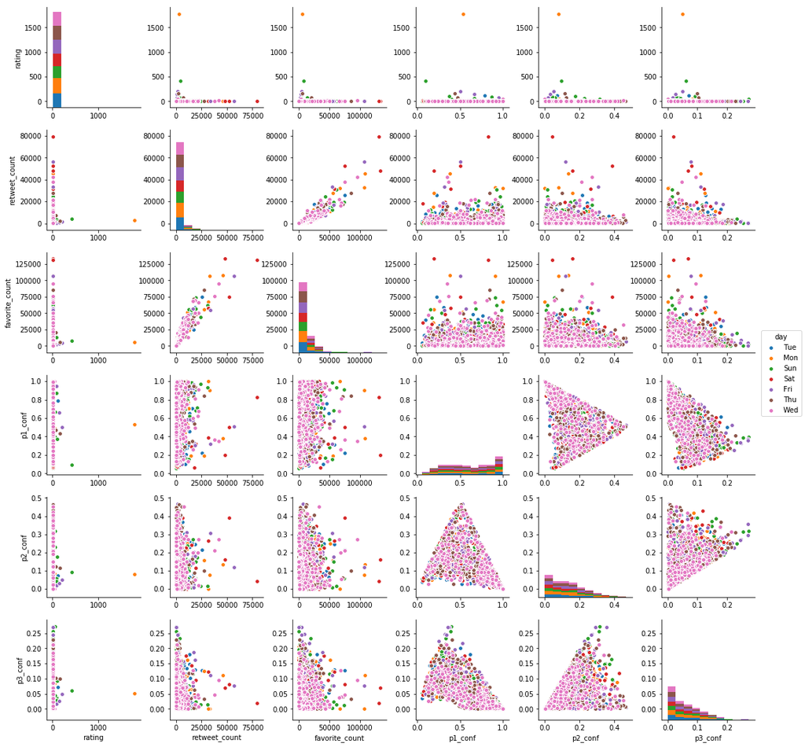

```python
sns.pairplot(df_master, vars=["rating", "retweet_count", "favorite_count", "p1_conf", "p2_conf", "p3_conf"], hue="day");
```

- From the chart we can see the positive correlation between retweet_count and favorite_count

### 2. Relationship between Rating and retweet counts

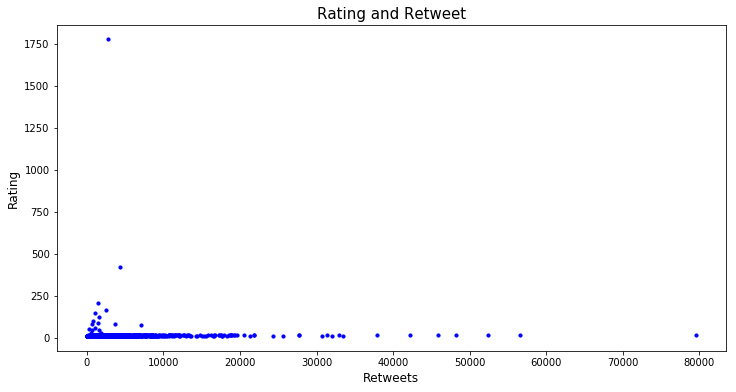

```python
#Relationship between Rating and retweet counts
df_master.plot.scatter(x='retweet_count',y='rating',s=10,c='blue',figsize=(12,6));

# chart labels
plt.xlabel('Retweets', fontsize=12);
plt.ylabel('Rating', fontsize=12)
plt.title('Rating and Retweet', fontsize=15);
```